# Biases in Predicting Recidivism: How COMPAS Failed and Alternate Models – Team 2

# Abstract

Northpointe created a recidivism measure aimed at classifying individuals as low and high risk. However, their models and measures are biased against Black defendants. Our group aimed to eliminate this bias by analyzing 8 different classification models. We found that Quadratic Discriminant Models yielded the best misclassification rates, but were still biased. We discuss that QDA did very well in capturing the trends in the data; however, we discuss the fact that the justice department’s dataset may be skewed in a way that leads data scientists to believe models are biased.

# Introduction and Description

We decided to look at the ProPublica COMPAS data set. COMPAS is a scoring model developed by Northpointe that is used to predict the likelihood that a criminal will recidivate. The use of such a model is typically used to determine bail amounts and to determine the placement of correctional officers / how to treat the offenders (Angwin et al. 2016). In 2016, the analysis by ProPublica uncovered that, despite being marketed as fair across all gender and race groups, the COMPAS algorithm incorrectly flagged certain groups as recidivating more often. Specifically, they found that Black defendants (who did not recidivate) were flagged 45% of the time, but only 23% of White defendants were flagged (Angwin et al. 2016). Further, 48% of White defendants were marked as low risk, compared to 28% of Black defendants. Even after controlling for other variables, they found that Black defendants were 77% more likely to be flagged for a **violent** crime than White defendants (Angwin et al. 2016). It is clear that the COMPAS algorithm is biased toward Black defendants, which has a number of negative implications for them that White defendants are less likely to experience. Our group’s goal is to find a classification algorithm that correctly predicts recidivism, while having higher accuracy, and being less biased towards racial groups, than the COMPAS algorithm.

We chose to look at classification accuracy because the issue with COMPAS was that it had high bias particularly among Black defendants. Higher classification rates of recidivism and violent recidivism towards Black compared to White defendants led us to believe that this was a misclassification problem – Black defendants were being misclassified while White defendants were not. We also observed and calculated the Concordance rate of our chosen model. Concordance is defined as “probability that a randomly selected subject who experienced the outcome will have a higher predicted probability of having the outcome occur than a randomly selected subject who did not experience the outcome” (Logan 2013). Northpointe used concordance as the accuracy measure of their cox model, and we believed that we could only compare predictive accuracy in our model, with COMPAS, via concordance.

We begin our report by discussing Exploratory Data Analysis.

# Exploratory Data Analysis

We produced a number of plots and statistical tests to determine the distributions of the ProPublica data set. To remain constant across both of the analyses, we used their provided database, and eliminated the exact observations that ProPublica did. We also deleted several other columns because our group determined they would not be useful predictors (i.e., first and last name) for recidivism. We also deleted COMPAS columns as we are not interested in using COMPAS data – we’re trying to create a better model separate from COMPAS. In this exploratory analysis, we found the following:

```r
#Read in Recidivism Data
data = read.csv("recid_data.csv")

#Data Preparation
data <- mutate(data, sex = as.factor(sex)) %>%
  within(sex <- relevel(sex, ref = 2)) %>%
  mutate(race = as.factor(race)) %>%
  within(race <- relevel(race, ref = 3)) %>%
  mutate(age_cat = as.factor(age_cat)) %>%
  mutate(c_charge_degree = as.factor(c_charge_degree)) %>%
  mutate(is_recid = as.factor(is_recid)) %>%
  mutate(is_violent_recid = as.factor(is_violent_recid))

#Removing Extraneous Info
data = subset(data, select = -c(X, person_id, age_cat, dob, name, first, last,
                                c_arrest_date, c_offense_date, r_case_number,
                                compas_screening_date, r_offense_date, r_jail_in, r_jail_out, vr_case_number,
                                vr_offense_date, decile_score, num_r_cases, c_days_from_compas,
                                r_charge_degree, r_days_from_arrest, vr_charge_degree))

#Remove Problem c_charge_degree values
x1 = which(data$c_charge_degree=="(CO3)")
data = data[-x1,]

x2 = which(data$c_charge_degree=="(CT)")
data = data[-x2,]

x3 = which(data$c_charge_degree=="(TCX)")
data = data[-x3,]

x4 = which(data$c_charge_degree=="(X)")
data = data[-x4,]

x5 = which(data$c_charge_degree=="(F5)")
data = data[-x5,]

x6 = which(data$c_charge_degree=="(F6)")
data = data[-x6,]

x7 = which(data$c_charge_degree=="(NI0)")
data = data[-x7,]

rm(list=setdiff(ls(), "data"))
```

## Correlation between Variables

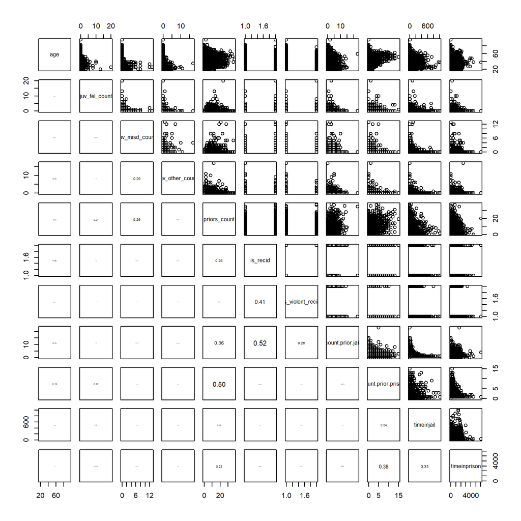

```r
panel.cor <- function(x, y, digits = 2, prefix = "", cex.cor, ...) {
    usr <- par("usr"); on.exit(par(usr))
    par(usr = c(0, 1, 0, 1))
    r <- abs(cor(x, y, use = "complete.obs"))
    txt <- format(c(r, 0.123456789), digits = digits)[1]
    txt <- paste0(prefix, txt)
    if(missing(cex.cor)) cex.cor <- 0.8/strwidth(txt)
    text(0.5, 0.5, txt, cex = cex.cor * r)
}

pairs(data[,c("age", "juv_fel_count","juv_misd_count","juv_other_count", "priors_count","is_recid","is_violent_recid","count.prior.jail","count.prior.prison","timeinjail","timeinprison" )], lower.panel = panel.cor)
```

> We did not believe that there were any strong collinearity concerns in this data. We defined strong collinearity as if the correlation was .70 or greater. Via our pairs plot, we did not find any strong concerns, and as such, left all 14 of our variables in the data set.

## EDA – Two Year Nonviolent Recidivism

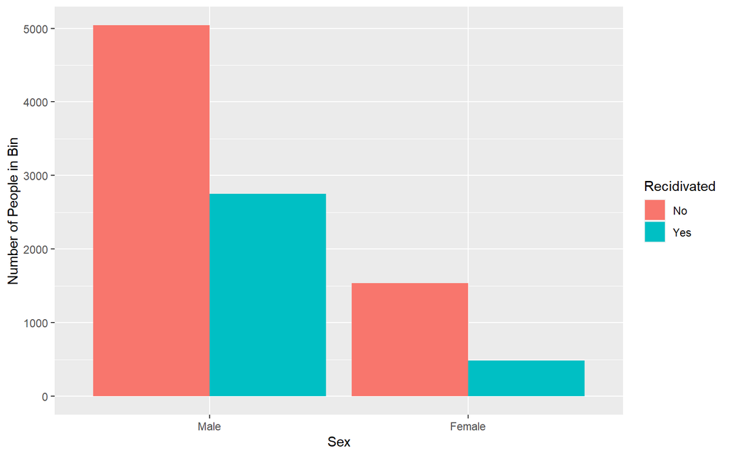

```r
#Sex

ggplot(data, aes(x = sex, fill = as.factor(is_recid))) + geom_bar(position = 'dodge') +
  scale_fill_discrete(name = "Recidivated", labels = c("No", "Yes")) +
  xlab('Sex') +
  ylab('Number of People in Bin')
```

```r
data$is_recid <- as.numeric(data$is_recid)
data$is_recid[data$is_recid == 1] <- 0
data$is_recid[data$is_recid == 2] <- 1

t.test(is_recid ~ sex, data)
```

```
##
##  Welch Two Sample t-test
##
## data:  is_recid by sex
## t = 10.295, df = 3451.2, p-value < 2.2e-16
## alternative hypothesis: true difference in means is not equal to 0
## 95 percent confidence interval:
##  0.09116776 0.13406283
## sample estimates:
##   mean in group Male mean in group Female
##            0.3529714            0.2403561
```

> A greater proportion of males (M = .353) recidivate than females (M = .240), and this is statistically significant at the .05 level.

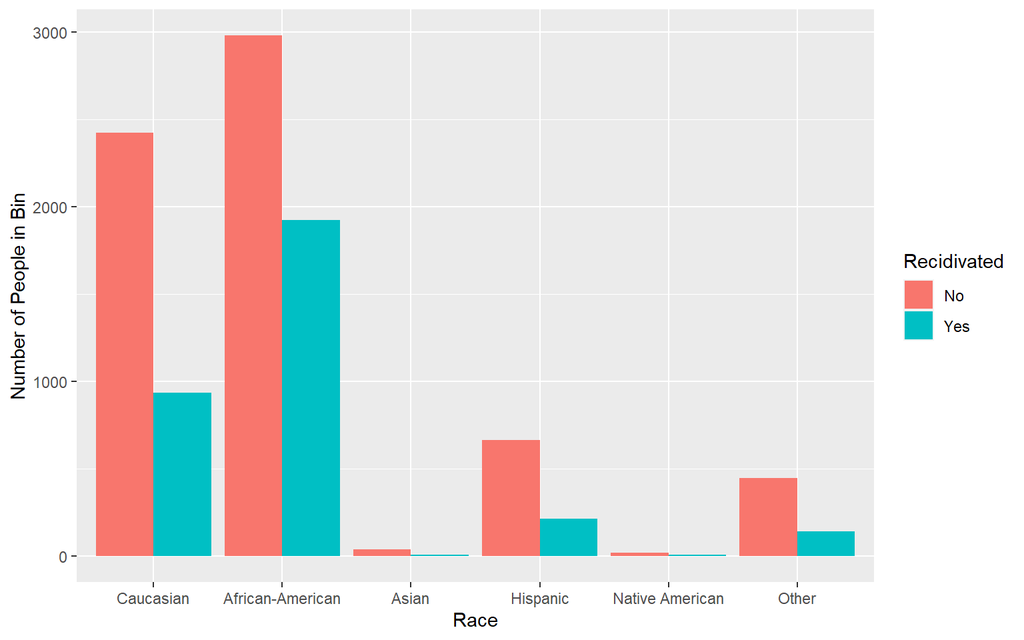

```r
#Race
ggplot(data, aes(x = race, fill = as.factor(is_recid))) + geom_bar(position = 'dodge') +
  scale_fill_discrete(name = "Recidivated", labels = c("No", "Yes")) +
  xlab('Race') +
  ylab('Number of People in Bin')
```

```r
summary(aov(is_recid ~ race, data))
```

```
##               Df Sum Sq Mean Sq F value Pr(>F)
## race           5   39.8   7.952   36.63 <2e-16 ***
## Residuals   9807 2129.1   0.217
## ---
## Signif. codes:  0 '***' 0.001 '**' 0.01 '*' 0.05 '.' 0.1 ' ' 1
```

| race | is_recid |
| --- | --- |
| Caucasian | 0.28 |
| African-American | 0.39 |
| Asian | 0.21 |
| Hispanic | 0.25 |
| Native American | 0.28 |
| Other | 0.24 |

```r
summary(aov(is_recid ~ race, data[data$race != "African-American",]))
```

```
##               Df Sum Sq Mean Sq F value Pr(>F)
## race           4    1.4  0.3461   1.768  0.132
## Residuals   4904  960.0  0.1958
```

> African-Americans have the greatest proportion of individuals recidivating (M = .390) than other races. This is statistically significant at the .05 level. If we remove African-Americans from the data set, this no longer is statistically significant.

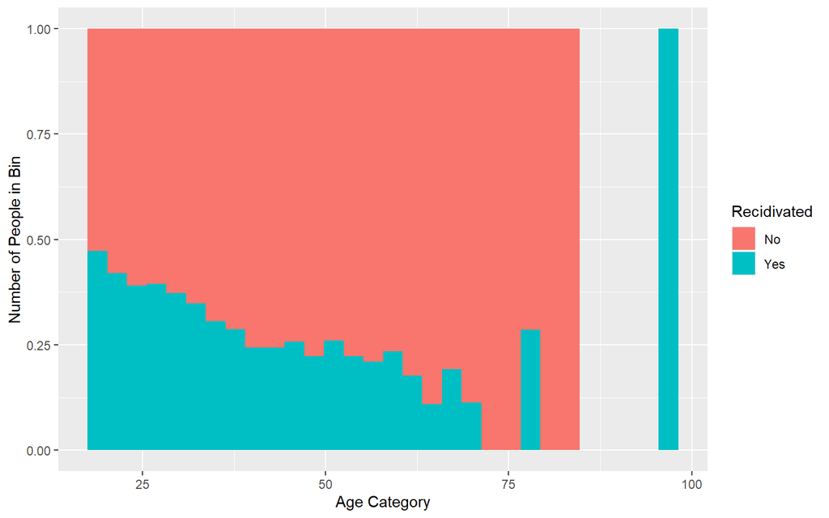

```r
#Age
ggplot(data, aes(x = age, fill = as.factor(is_recid))) + geom_histogram(position = 'fill') +
  scale_fill_discrete(name = "Recidivated", labels = c("No", "Yes")) +
  xlab('Age Category') +
  ylab('Number of People in Bin')
```

> Younger people appear to be more likely to recidivate more than older people.

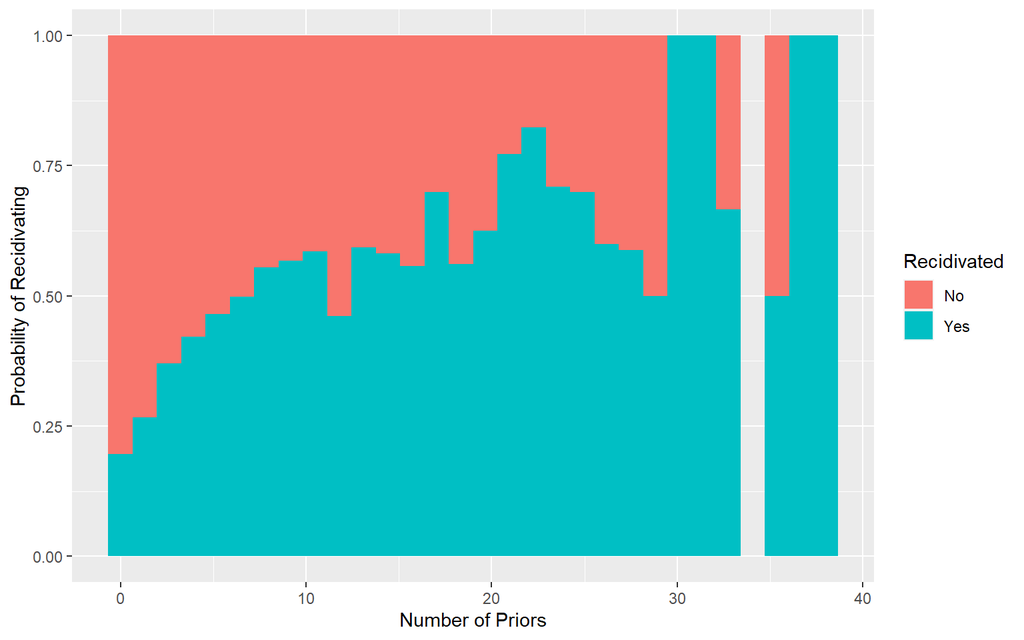

```r
#Priors Count
ggplot(data, aes(x = priors_count, fill = as.factor(is_recid))) + geom_histogram(position = 'fill') +
  scale_fill_discrete(name = "Recidivated", labels = c("No", "Yes")) +
  xlab('Number of Priors') +
  ylab('Probability of Recidivating')
```

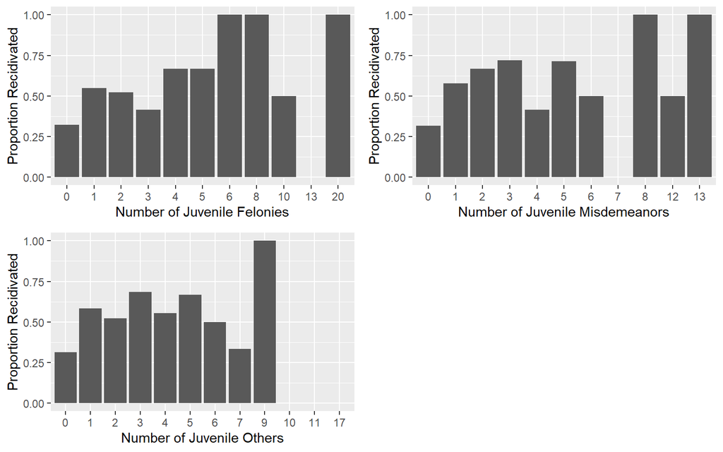

```r
#Juvenile Counts
juv.fel.plot <- data %>% dplyr::group_by(juv_fel_count) %>% dplyr::summarize(mean = mean(is_recid)) %>%
  ggplot(aes(x = as.factor(juv_fel_count), y = mean)) +
  geom_bar(stat = 'identity') +
  ylab('Proportion Recidivated') +
  xlab('Number of Juvenile Felonies')

juv.misd.plot <- data %>% dplyr::group_by(juv_misd_count) %>% dplyr::summarize(mean = mean(is_recid)) %>%
  ggplot(aes(x = as.factor(juv_misd_count), y = mean)) + geom_bar(stat = 'identity') +
  ylab('Proportion Recidivated') +
  xlab('Number of Juvenile Misdemeanors')

juv.other.plot <- data %>% dplyr::group_by(juv_other_count) %>% dplyr::summarize(mean = mean(is_recid)) %>%
  ggplot(aes(x = as.factor(juv_other_count), y = mean)) + geom_bar(stat = 'identity') +
  ylab('Proportion Recidivated') +
  xlab('Number of Juvenile Others')

grid.arrange(juv.fel.plot, juv.misd.plot, juv.other.plot, ncol = 2)
```

> It appears that the higher the number of priors, the more likely a person is to recidivate. There also appears to be no real full relationship between the number of juvenile priors and probability of recidivating.

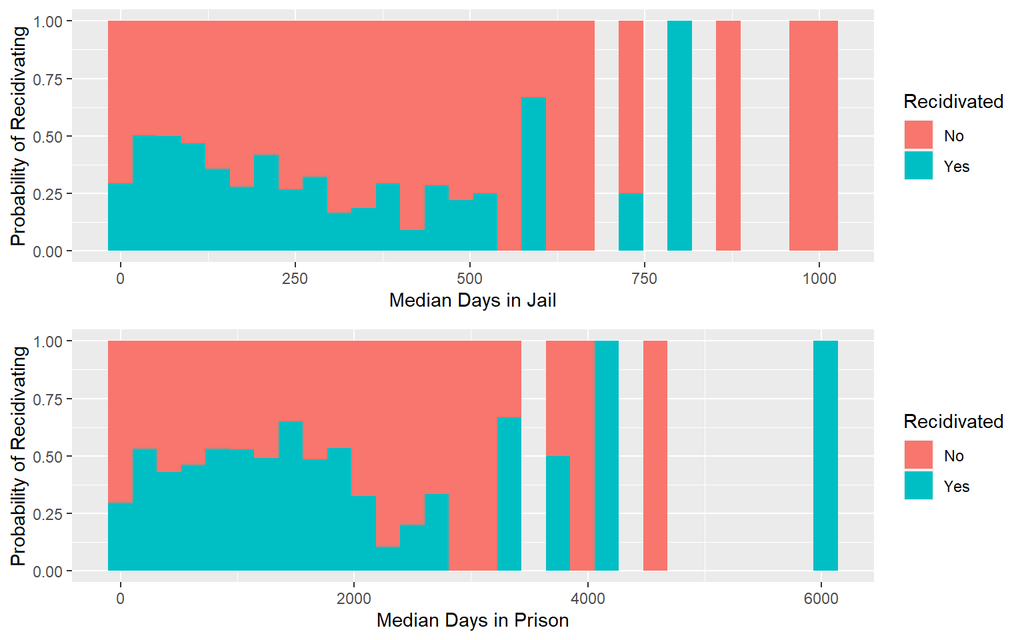

```r
#Time in Jail / Prison
jail.plot <- ggplot(data, aes(x = timeinjail, fill = as.factor(is_recid))) + geom_histogram(position = 'fill') +
  xlab('Median Days in Jail') +
  ylab('Probability of Recidivating') +
  scale_fill_discrete(name = "Recidivated", labels = c("No", "Yes"))

prison.plot <- ggplot(data, aes(x = timeinprison, fill = as.factor(is_recid))) + geom_histogram(position = 'fill') +
  xlab('Median Days in Prison') +
  ylab('Probability of Recidivating') +
  scale_fill_discrete(name = "Recidivated", labels = c("No", "Yes"))

grid.arrange(jail.plot, prison.plot)
```

```r
data$is_recid <- as.factor(data$is_recid)
```

> Similarly, there appears to be no convincing relationship between the number of days spent in prison / jail and recidivating.

## EDA – Violent Recidivism

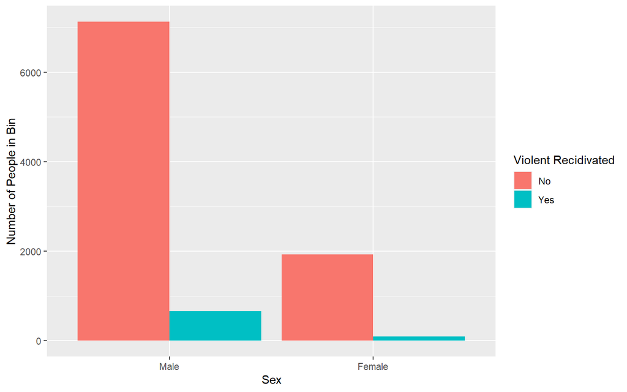

```r
data$is_violent_recid <- as.numeric(data$is_violent_recid)
data$is_violent_recid[data$is_violent_recid == 1] <- 0
data$is_violent_recid[data$is_violent_recid == 2] <- 1

#Sex

ggplot(data, aes(x = sex, fill = as.factor(is_violent_recid))) + geom_bar(position = 'dodge') +
  scale_fill_discrete(name = "Violent Recidivated", labels = c("No", "Yes")) +
  xlab('Sex') +
  ylab('Number of People in Bin')
```

```r
t.test(is_violent_recid ~ sex, data)
```

```
##
##  Welch Two Sample t-test
##
## data:  is_violent_recid by sex
## t = 6.7221, df = 4042.2, p-value = 2.041e-11
## alternative hypothesis: true difference in means is not equal to 0
## 95 percent confidence interval:
##  0.02699855 0.04923146
## sample estimates:
##   mean in group Male mean in group Female
##           0.08509819           0.04698318
```

> Males (M = .085) violently recidivate more often than females (M = .047) and this is statistically significant at the .05 level.

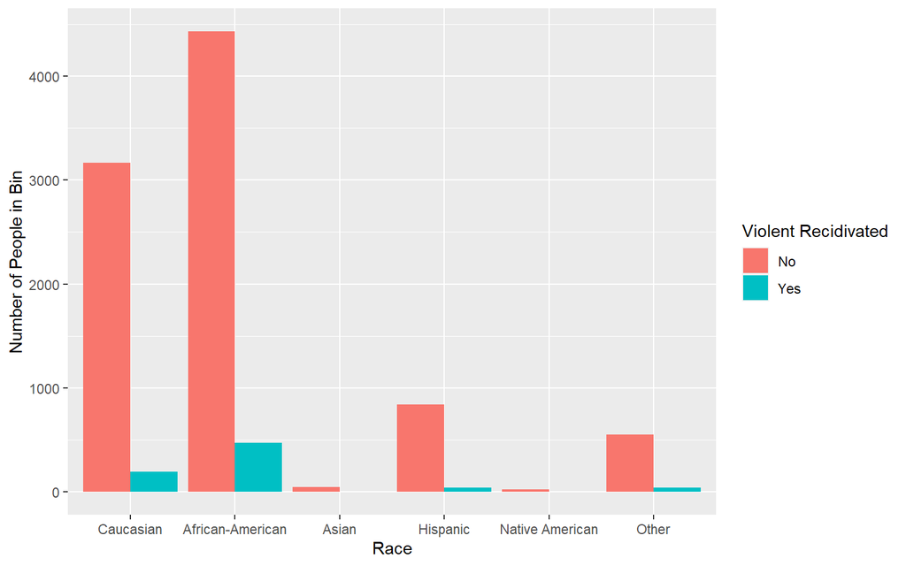

```r
#Race
ggplot(data, aes(x = race, fill = as.factor(is_violent_recid))) + geom_bar(position = 'dodge') +
  scale_fill_discrete(name = "Violent Recidivated", labels = c("No", "Yes")) +
  xlab('Race') +
  ylab('Number of People in Bin')
```

```r
summary(aov(is_violent_recid ~ race, data))
```

```
##               Df Sum Sq Mean Sq F value   Pr(>F)
## race           5    4.1  0.8273   11.67 2.89e-11 ***
## Residuals   9807  695.3  0.0709
## ---
## Signif. codes:  0 '***' 0.001 '**' 0.01 '*' 0.05 '.' 0.1 ' ' 1
```

| race | is_violent_recid |
| --- | --- |
| Caucasian | 0.06 |
| African-American | 0.10 |
| Asian | 0.06 |
| Hispanic | 0.05 |
| Native American | 0.14 |
| Other | 0.07 |

```r
summary(aov(is_violent_recid ~ race, data[data$race != "African-American",]))
```

```
##               Df Sum Sq Mean Sq F value Pr(>F)
## race           4   0.36 0.09113   1.678  0.152
## Residuals   4904 266.32 0.05431
```

> African Americans (M = .10) and Native Americans (M = .14) violently recidivate more often than other races, and this is statistically significant at the .05 level. If we remove African-Americans from the data set, these differences are no longer statistically significant.

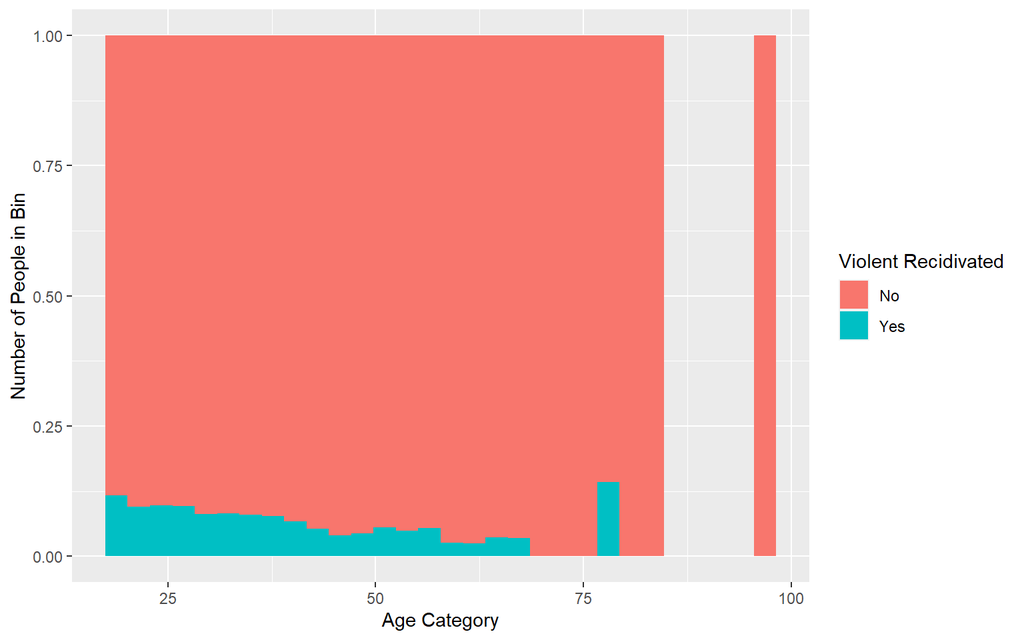

```r
#Age Category
ggplot(data, aes(x = age, fill = as.factor(is_violent_recid))) + geom_histogram(position = 'fill') +
  scale_fill_discrete(name = "Violent Recidivated", labels = c("No", "Yes")) +
  xlab('Age Category') +
  ylab('Number of People in Bin')
```

> Younger individuals appear more likely to violently recidivate than older individuals

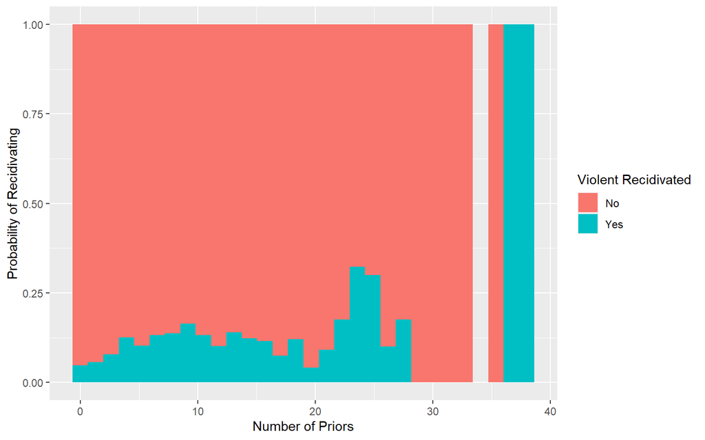

```r
#Priors Count
ggplot(data, aes(x = priors_count, fill = as.factor(is_violent_recid))) + geom_histogram(position = 'fill') +
  scale_fill_discrete(name = "Violent Recidivated", labels = c("No", "Yes")) +
  xlab('Number of Priors') +
  ylab('Probability of Recidivating')
```

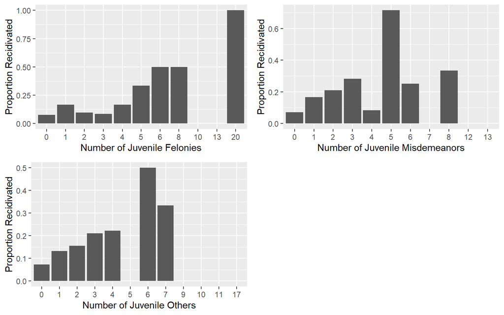

```r
#Juvenile Counts
juv.fel.plot <- data %>% dplyr::group_by(juv_fel_count) %>% dplyr::summarize(mean = mean(is_violent_recid)) %>%
  ggplot(aes(x = as.factor(juv_fel_count), y = mean)) + geom_bar(stat = 'identity') +
  ylab('Proportion Recidivated') +
  xlab('Number of Juvenile Felonies')

juv.misd.plot <- data %>% dplyr::group_by(juv_misd_count) %>% dplyr::summarize(mean = mean(is_violent_recid)) %>%
  ggplot(aes(x = as.factor(juv_misd_count), y = mean)) + geom_bar(stat = 'identity') +
  ylab('Proportion Recidivated') +
  xlab('Number of Juvenile Misdemeanors')

juv.other.plot <- data %>% dplyr::group_by(juv_other_count) %>% dplyr::summarize(mean = mean(is_violent_recid)) %>%
  ggplot(aes(x = as.factor(juv_other_count), y = mean)) + geom_bar(stat = 'identity') +
  ylab('Proportion Recidivated') +
  xlab('Number of Juvenile Others')

grid.arrange(juv.fel.plot, juv.misd.plot, juv.other.plot, ncol = 2)
```

> The higher the number of priors, the more likely it appears that a person is to violently recidivate. The higher the number of juvenile priors, the more likely it appears that a person is to violently recidivate.

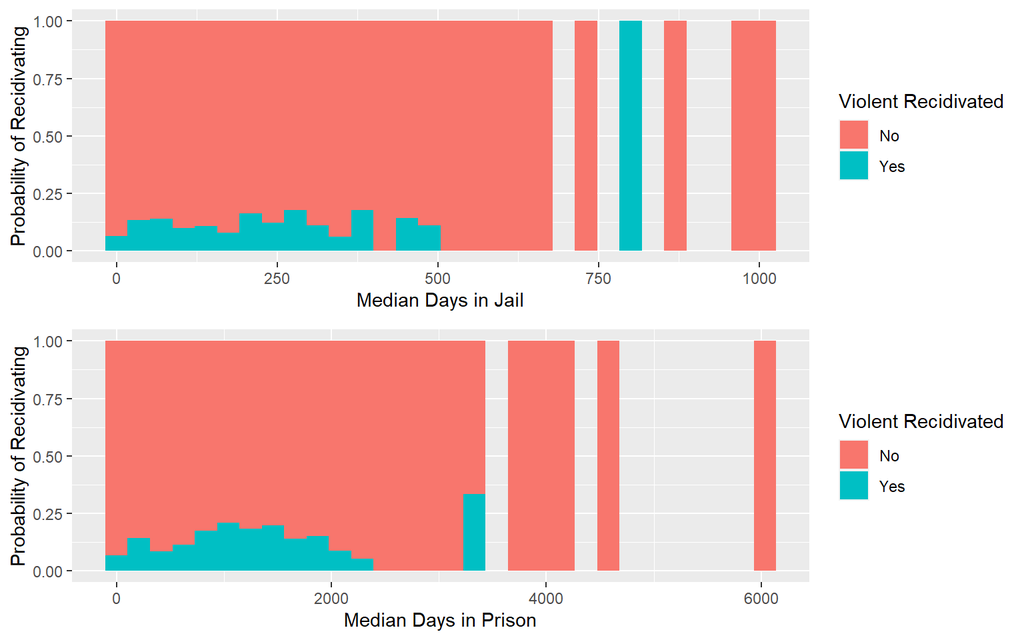

```r
#Time in Jail / Prison
jail.plot <- ggplot(data, aes(x = timeinjail, fill = as.factor(is_violent_recid))) + geom_histogram(position = 'fill') +
  xlab('Median Days in Jail') +
  ylab('Probability of Recidivating') +
  scale_fill_discrete(name = "Violent Recidivated", labels = c("No", "Yes"))

prison.plot <- ggplot(data, aes(x = timeinprison, fill = as.factor(is_violent_recid))) + geom_histogram(position = 'fill') +
  xlab('Median Days in Prison') +
  ylab('Probability of Recidivating') +
  scale_fill_discrete(name = "Violent Recidivated", labels = c("No", "Yes"))

grid.arrange(jail.plot, prison.plot)
```

```r
data$is_violent_recid <- as.factor(data$is_violent_recid)
```

> There is no strong observable relationship between the number of days spent in prison and jail on the likelihood of violently recidivating.

# Methodology

For our model selection, we analyzed the use of 8 different models (for both Two Year and Violent Recidivism), resulting in a total of 16 different models that we explored. We used the following models in our exploration of the data:

1. Logistic Regression
2. Naive Bayes Classifier
3. Linear Discriminant Analysis (LDA)
4. Quadratic Discriminant Analysis (QDA)
5. Random Forest
6. Neural Network
7. K-Nearest Neighbors
8. Linear Regression.

## Summary

Each group member was assigned two models. We decided two look at the two models for both Two-Year Recidivism and Violent Recidivism. In total, each person created 4 different models, and compared each of their two models within their own analysis, and across each group members analysis. Each group member also used their corresponding model’s feature selection, or another feature selection that they thought fit their model the best. In the end, we had 16 models that we compared, with the QDA model having the lowest misclassification rate. This QDA model is the model that we base our predictions and bias findings on.

We start with Logistic Regression and Naive Bayes.

## JOHN – Logistic Regression and Naive Bayes Classifier

Before I started, I removed problematic values from the ‘c_charge_degree’ variable. When splitting into training and test data sets for using the Validation Set approach, the trained models would encounter observations of the variable it had never seen before. This was always due to only a single person having a specific c_charge_degree, so we thought it best to remove them.

We settled on the use of 14 variables in our data set. For my section, I did not want to assume that using all 14 variables would give the best model. In my research, I found that using best subsets, forwards selection, and backwards selection is not appropriate in today’s world. Flom and Castell (2013) suggest that the use of these best subset selections results in small standard errors, narrow confidence intervals, and they can exacerbate any collinearity problems. For something as important as predicting recidivism, I believed the use of LASSO modeling and feature selection would be appropriate, and this is indeed what Flom and Castell recommend for model selection. I also utilized the r package `boruta`, which finds the most important predictors for the model via Random Forest. Use of these predictors can result in overfitting, but they are included for completeness. As such, I usually fit a full model, model with lasso-selected features, and a model with boruta-selected features, and all three would be compared.

### Two Year Recidivism

#### Preparing Lasso Feature Selection

```r
# Define x matrix and y vector for use with glmnet
x <- model.matrix(is_recid~., data)[,-1]
y <- data$is_recid
grid=10^seq(10,-2, length =100) #Need a preselected grid of lambdas -- glmnet won't work with a single lambda value
```

#### Feature Selection Two Year Recidivism

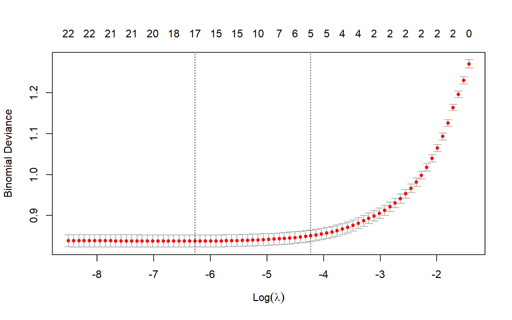

```r
# Split data into test and train
train <- sample(1:nrow(x), nrow(x)/2)
test <- (-train)
y.test <- y[test]

cv.logit <- cv.glmnet(x[train,], y[train], alpha = 1, family = "binomial")

plot(cv.logit)
```

```r
#Logistic Lasso Model
lasso.model <- glmnet(x[train, ], y[train], alpha = 1, family = "binomial", lambda = grid)

lasso.coef <- predict(lasso.model, type = 'coefficients', s = cv.logit$lambda.min)

lasso.coef[lasso.coef != 0] #Includes Sex, Race, age, juv_misd_count, priors_count, is_violent_recid, count.prior.jail
```

```
## <sparse>[ <logic> ] : .M.sub.i.logical() maybe inefficient
```

```
## [1] -2.11657335 -0.04844816  0.08518812 -0.01484361  0.03407172  3.80717910
## [7]  0.78552549
```

```r
lasso.preds <- predict(lasso.model, s = cv.logit$lambda.min, newx = x[test, ], type = "response")

#Boruta Feature Selection
y <- data$is_recid
x <- subset(data, select = -c(is_recid))
boruta_output <- Boruta(x, y)

boruta_output$finalDecision #All Variables, except c_charge_degree are important
```

```
##                sex               race                age      juv_fel_count
##          Confirmed          Confirmed          Confirmed          Confirmed
##     juv_misd_count    juv_other_count       priors_count    c_charge_degree
##          Confirmed          Confirmed          Confirmed           Rejected
##   is_violent_recid   count.prior.jail count.prior.prison         timeinjail
##          Confirmed          Confirmed          Confirmed          Confirmed
##       timeinprison
##          Confirmed
## Levels: Tentative Confirmed Rejected
```

#### Predicting Two Year Recidivism – Logistic Regression

```r
#Two Year Recidivism -- Logistic and Naive Bayes
# Define x matrix and y vector for use with glmnet
x <- model.matrix(is_recid~., data)[,-1]
y <- data$is_recid
grid=10^seq(10,-2, length =100) #Need a preselected grid of lambdas -- glmnet won't work with a single lambda value

#Create Sample Sets

train <- sample(1:nrow(data), nrow(data)/2)

data.train <- data[train, ]
data.test <- data[-train, ]

#Train Logistic Regression, with features selected by Boruta via Importance
logit.all <- glm(is_recid~. - c_charge_degree, data = data.train, family = "binomial")

logit.all.probs <- logit.all %>% predict(data.test, type = "response")
log.all.pred <- rep("No Recid", nrow(data.test))
log.all.pred[logit.all.probs > .5] <- "Yes Recid"

log.all.table <- table(log.all.pred, data.test$is_recid)
log.all.error <- (log.all.table[1, 2] + log.all.table[2, 1])/nrow(data.test)

#Train Normal Logistic Regression, with features selected by Logistic Lasso

#Predict Logistic Probabilities
logit <- glm(is_recid~sex + race + age + juv_misd_count + priors_count +
               is_violent_recid + count.prior.jail, data = data.train, family = "binomial")

logit.probs <- logit %>% predict(data.test, type = "response")

#Create Tables for Logistic and Lasso-Logistic Models
log.pred <- rep("No Recid", nrow(data.test))
lass.pred <- rep("No Recid", nrow(data.test))
log.pred[logit.probs > .5] <- "Yes Recid"
lass.pred[lasso.preds > .5] <- "Yes Recid"

#Find Error Rates
log.table <- table(log.pred, data.test$is_recid)
log.error <- (log.table[1, 2] + log.table[2, 1])/nrow(data.test)

lass.table <- table(lass.pred, data.test$is_recid)
lass.error <- (lass.table[1, 2] + lass.table[2, 1])/nrow(data.test)

#Compare Logistic Models
log.error < log.all.error
```

```
## [1] TRUE
```

```r
#We will keep the logistic regression
log.error < lass.error
```

```
## [1] TRUE
```

> Via comparison of the Logistic Lasso misclassification error, and the Logistic Regression misclassification error, I find that the logistic regression has the lowest misclassification rate.

#### Predicting Two Year Recidivism – Naive Bayes Classifier

```r
#Preparing Naive Bayes

#Naive Bayes -- Features Selected by Lasso
nb.model <- NaiveBayes(data = data.train, is_recid~sex + race + age + juv_misd_count + priors_count +
               is_violent_recid + count.prior.jail, usekernel = TRUE)
nb.pred <- nb.model %>% predict(data.test)

#Naive Bayes -- Features selected by Boruta
nb.all.model <- NaiveBayes(data = data.train, is_recid~. - c_charge_degree, usekernel = TRUE)
nb.pred.all <- nb.all.model %>% predict(data.test)

#Calculate Naive Bayes Error
nb.table <- table(nb.pred$class, data.test$is_recid)
nb.error <- (nb.table[1, 2] + nb.table[2, 1])/nrow(data.test)

nb.table.all <- table(nb.pred.all$class, data.test$is_recid)
nb.error.all <- (nb.table.all[1, 2] + nb.table.all[2, 1])/nrow(data.test)

nb.error < nb.error.all #Will keep the less complicated model
```

```
## [1] TRUE
```

```r
#We will keep logistic regression rather than Naive Bayes, although they are very close!
log.error < nb.error
```

```
## [1] TRUE
```

> I found that the Naive Bayes model with features selected by the logistic lasso had the best error out of both Naive Bayes models, but the Logistic model with lasso selected features had the best misclassification rate out of all of the models in this section.

#### 10-Fold CV Error for Two Year Recidivism

```r
control <- trainControl(method = "cv")

nb.lasso.cv <- 1 - train(is_recid~sex + race + age + juv_misd_count +
                 priors_count + is_violent_recid + count.prior.jail, data = data, trControl = control, method =
                   'naive_bayes')$results[2, "Accuracy"]

nb.boruta.cv <- 1 - train( is_recid~. - c_charge_degree, data = data, trControl = control,
                           method = 'naive_bayes')$results[2, "Accuracy"]

logit.boruta.cv <- 1 - train(is_recid~. - c_charge_degree, data = data, trControl = control,
                         method = 'glm', family = 'binomial')$results[1, "Accuracy"]

logit.lasso.cv <- 1 - train(is_recid~sex + race + age + juv_misd_count + priors_count +
               is_violent_recid + count.prior.jail, data = data, trControl = control, method = 'glm',
               family = 'binomial')$results[1, "Accuracy"]

lasso.cv <- cv.glmnet(x, y, alpha = 1, lambda = grid, family = "binomial", type.measure = "class")$cvm[100]

which.min(c(nb.lasso.cv, nb.boruta.cv, logit.boruta.cv, logit.lasso.cv, lasso.cv))
```

```
## [1] 4
```

```r
#CV confirms Logistic Regression with Lasso-Selected Coefficients
```

> The Cross Validation finds that, just like Validation Set Approach, that the Logistic Regression with Lasso-Selected Coefficients results in the best misclassification rate.

#### ROC Curve with Selected Model - Two Year Recidivism

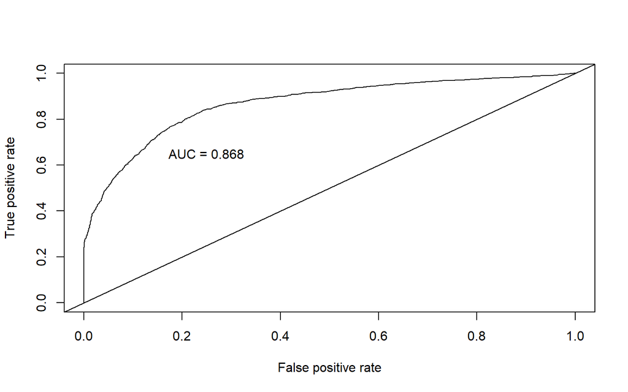

```r
log.preds <- logit %>% predict(data.test, type = "response")
log.perf <- prediction(log.preds, data.test$is_recid)
roc.perf <- performance(log.perf, measure = "tpr", x.measure = "fpr")
auc.train <- performance(log.perf, measure = "auc")
auc.train <- auc.train@y.values

plot(roc.perf)
abline(a=0, b= 1)
text(x = .25, y = .65 ,paste("AUC = ", round(auc.train[[1]],3), sep = ""))
```

> The ROC curve shows that this is a good model for the classification of two year recidivism.

#### Findings & Bias Analysis

```r
#Two Year Recid

data.test$predictions <- log.pred
data.test$predictions[data.test$predictions == "No Recid"] <- 0
data.test$predictions[data.test$predictions == "Yes Recid"] <- 1
data.test$predictions <- as.numeric(data.test$predictions)

#Race
race.r <- ggplot(data.test, aes(x = race, fill = as.factor(predictions))) + geom_bar(position = 'dodge') +
  scale_fill_discrete(name = "Recidivated", labels = c("No", "Yes")) +
  xlab('Race') +
  ylab('Number of People in Bin')

summary(aov(predictions ~ race, data.test))
```

```
##               Df Sum Sq Mean Sq F value Pr(>F)
## race           5   24.7   4.947   28.47 <2e-16 ***
## Residuals   4901  851.5   0.174
## ---
## Signif. codes:  0 '***' 0.001 '**' 0.01 '*' 0.05 '.' 0.1 ' ' 1
```

```r
kable(data.test %>%
  group_by(race) %>%
  summarize_at(c("predictions"), mean), digits = 2)
```

| race | predictions |
| --- | --- |
| Caucasian | 0.18 |
| African-American | 0.30 |
| Asian | 0.15 |
| Hispanic | 0.12 |
| Native American | 0.06 |
| Other | 0.15 |

```r
summary(aov(predictions ~ race, data.test[data.test$race != "African-American",]))
```

```
##               Df Sum Sq Mean Sq F value Pr(>F)
## race           4    1.6  0.3963   2.883 0.0214 *
## Residuals   2485  341.6  0.1375
## ---
## Signif. codes:  0 '***' 0.001 '**' 0.01 '*' 0.05 '.' 0.1 ' ' 1
```

```r
#Age
age.r <- ggplot(data.test, aes(x = age, fill = as.factor(predictions))) + geom_histogram(position = "fill") +
  scale_fill_discrete(name = "Recidivated", labels = c("No", "Yes")) +
  xlab('Age') +
  ylab('Number of People in Bin')

#Sex
sex.r <- ggplot(data.test, aes(x = sex, fill = as.factor(predictions))) + geom_bar(position = 'dodge') +
  scale_fill_discrete(name = "Recidivated", labels = c("No", "Yes")) +
  xlab('Sex') +
  ylab('Number of People in Bin')

t.test(predictions ~ sex, data.test)
```

```
##
##  Welch Two Sample t-test
##
## data:  predictions by sex
## t = 11.11, df = 2125.1, p-value < 2.2e-16
## alternative hypothesis: true difference in means is not equal to 0
## 95 percent confidence interval:
##  0.1138132 0.1626041
## sample estimates:
##   mean in group Male mean in group Female
##            0.2618802            0.1236715
```

```r
kable(data.test %>%
  group_by(sex) %>%
  summarize_at(c("predictions"), mean), digits = 2)
```

| sex | predictions |
| --- | --- |
| Male | 0.26 |
| Female | 0.12 |

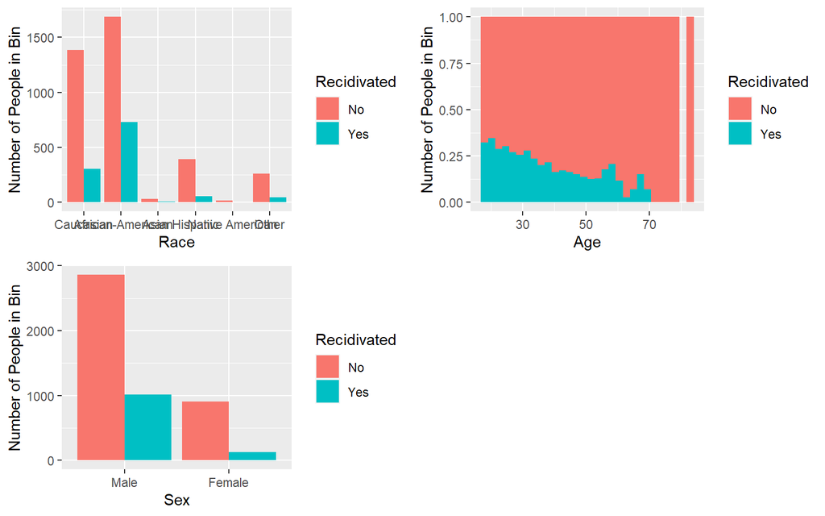

```r
grid.arrange(race.r, age.r, sex.r, ncol = 2)
```

For this variable, I fit 3 models – Logistic Lasso, regular logistic with lasso-selected predictors, and regular logistic with boruta-selected predictors. A full model is not in this report because the accuracy was the exact same as the boruta selected, and the boruta was a (slightly) less complicated model.

I found that the logistic model with lasso-selected predictors resulted in better accuracy (A = .179 vs. .181). This was also better than the logistic lasso (A = .179 vs. .393).

A Naive Bayes model was also fit in the same way as the logistic regression (i.e., 3 similar models). The lasso-selected predictors resulted in slightly better accuracy than the boruta-selected predictors (A = .200 vs. .207). However, the logistic model with lasso-selected predictors resulted in a better accuracy (A = .179 vs. .200). As such, the logistic model with lasso-selected predictors outperformed Naive Bayes in Two-Year Recidivism.

### Violent Recidivism

```r
rm(list=setdiff(ls(), "data"))
```

#### Preparing Lasso Feature Selection

```r
# Define x matrix and y vector for use with glmnet
x <- model.matrix(is_violent_recid~., data)[,-1]
y <- data$is_violent_recid
grid=10^seq(10,-2, length =100)
```

#### Feature Selection for Violent Recidivism

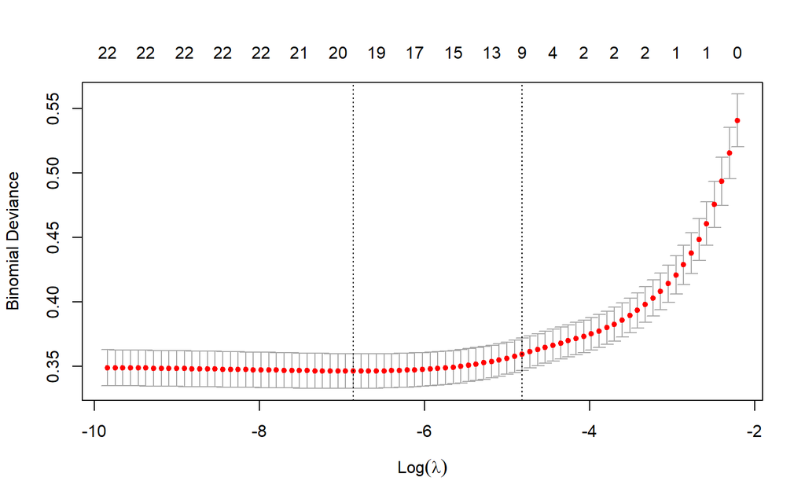

```r
# Split data into test and train
train <- sample(1:nrow(x), nrow(x)/2)
test <- (-train)
y.test <- y[test]

cv.logit <- cv.glmnet(x[train,], y[train], alpha = 1, family = "binomial")

plot(cv.logit)
```

```r
#Lasso Model
lasso.model <- glmnet(x[train, ], y[train], alpha = 1, family = "binomial", lambda = grid)

lasso.coef <- predict(lasso.model, type = 'coefficients', s = cv.logit$lambda.min)

lasso.coef[lasso.coef != 0] #timeinprison, count.prior.jail, is_recid, c_charge_degree, & juv_misd_count features
```

```
## <sparse>[ <logic> ] : .M.sub.i.logical() maybe inefficient
```

```
## [1] -5.03469778950  0.01544833729 -0.16031614974  0.22645369846  0.03171181625
## [6]  3.50401926134  0.09861978727  0.00038822236  0.00006599299
```

```r
lasso.preds <- predict(lasso.model, s = cv.logit$lambda.min, newx = x[test, ], type = "response")

#Boruta Feature Selection
y <- data$is_violent_recid
x <- subset(data, select = -c(is_violent_recid))
boruta_output <- Boruta(x, y)

boruta_output$finalDecision #All Variables, except sex, juv_fel_count, juv_misd_count, juv_other_count, count.prior.jail
```

```
##                sex               race                age      juv_fel_count
##           Rejected          Confirmed          Confirmed           Rejected
##     juv_misd_count    juv_other_count       priors_count    c_charge_degree
##           Rejected          Tentative          Confirmed          Confirmed
##           is_recid   count.prior.jail count.prior.prison         timeinjail
##          Confirmed           Rejected          Confirmed          Tentative
##       timeinprison
##          Confirmed
## Levels: Tentative Confirmed Rejected
```

> Lasso selected timeinprison, count.prior.jail, is_recid, c_charge_degree, & juv_misd_count as features. Boruta selected all variables except sex, juv_fel_count, juv_misd_count, juv_other_count, and count.prior.jail. I included full models for both Logistic and Naive Bayes because both of these feature selection models removed a large number of potential variables.

#### Predicting Violent Recidivism – Logistic Regression

```r
#Violent Recidivism -- Logistic and Naive Bayes

# Define x matrix and y vector for use with glmnet
x <- model.matrix(is_recid~., data)[,-1]
y <- data$is_recid
grid=10^seq(10,-2, length =100)

##Create the samples

train <- sample(1:nrow(data), nrow(data)/2)

data.train <- data[train, ]
data.test <- data[-train, ]

#Logistic with Lasso Regression
logit.lasso <- glm(is_violent_recid~timeinprison + count.prior.jail + is_recid + c_charge_degree +
                     juv_misd_count, data = data.train, family = "binomial")
logit.probs.lasso <- logit.lasso %>% predict(data.test, type = "response")

#Logistic with Boruta
logit.boruta <- glm(is_violent_recid~. -sex -juv_fel_count -juv_misd_count -juv_other_count
                    -count.prior.jail, data = data.train, family = "binomial")
logit.probs.boruta <- logit.boruta %>% predict(data.test, type = "response")

#Full Logistic Model
logit.full <- glm(is_violent_recid~., data = data.train, family = "binomial")
logit.probs.full <- logit.full %>% predict(data.test, type = "response")

#Create Tables for Logistic and Lasso-Logistic Models
log.lasso.pred <- rep("No Recid", nrow(data.test))
log.boruta.pred <- rep("No Recid", nrow(data.test))
log.full.pred <- rep("No Recid", nrow(data.test))
lass.pred <- rep("No Recid", nrow(data.test))

log.lasso.pred[logit.probs.lasso > .5] <- "Yes Recid"
log.boruta.pred[logit.probs.boruta > .5] <- "Yes Recid"
log.full.pred[logit.probs.full > .5] <- "Yes Recid"
lass.pred[lasso.preds > .5] <- "Yes Recid"

#Find Error Rates
log.lasso.table <- table(log.lasso.pred, data.test$is_violent_recid)
log.lasso.error <- (log.lasso.table[1, 2] + log.lasso.table[2, 1])/nrow(data.test)

log.boruta.table <- table(log.boruta.pred, data.test$is_violent_recid)
log.boruta.error <- (log.boruta.table[1, 2] + log.boruta.table[2, 1])/nrow(data.test)

log.full.table <- table(log.full.pred, data.test$is_violent_recid)
log.full.error <- (log.full.table[1, 2] + log.full.table[2, 1])/nrow(data.test)

lass.table <- table(lass.pred, data.test$is_violent_recid)
if(length(levels(as.factor(lass.pred))) == 1){
  lass.error <- lass.table[1, 2] /nrow(data.test)
}else{
  lass.error <- (lass.table[1, 2] + lass.table[2, 1])/nrow(data.test)
}

#Compare Logistics & Lasso
log.lasso.error #Choose the logistic lasso-selected model -- it's the least complicated
```

```
## [1] 0.07784797
```

```r
log.boruta.error
```

```
## [1] 0.07784797
```

```r
log.full.error
```

```
## [1] 0.07805176
```

```r
lass.error
```

```
## [1] 0.07682902
```

> We have four models, and, depending on the random subset via Validation and Test set approach, either the Logistic Lasso or the Logistic Regression with Lasso-Selected coefficients has the lowest misclassification rate. I choose to keep the Logistic Regression with Lasso-Selected coefficients because it is easier to interpret.

#### Predicting Violent Recidivism – Naive Bayes Classifier

```r
#Naive Bayes Lasso
nb.model.lasso <- NaiveBayes(data = data.train, is_violent_recid~timeinprison + count.prior.jail + is_recid +
                               c_charge_degree + juv_misd_count, usekernel = TRUE)
nb.pred.lasso <- nb.model.lasso %>% predict(data.test)

#Naive Bayes Boruta
nb.model.boruta <- NaiveBayes(data = data.train, is_violent_recid~. -sex -juv_fel_count -juv_misd_count -juv_other_count
                    -count.prior.jail, usekernel = TRUE)
nb.pred.boruta <- nb.model.boruta %>% predict(data.test)

#Naive Bayes Full
nb.model.full <- NaiveBayes(data = data.train, is_violent_recid ~., usekernel = TRUE)
nb.pred.full <- nb.model.full %>% predict(data.test)

#Calculate Naive Bayes Error
nb.table.full <- table(nb.pred.full$class, data.test$is_violent_recid)
nb.error.full <- (nb.table.full[1, 2] + nb.table.full[2, 1])/nrow(data.test)

nb.table.lasso <- table(nb.pred.lasso$class, data.test$is_violent_recid)
nb.error.lasso <- (nb.table.lasso[1, 2] + nb.table.lasso[2, 1])/nrow(data.test)

nb.table.boruta <- table(nb.pred.boruta$class, data.test$is_violent_recid)
nb.error.boruta <- (nb.table.boruta[1, 2] + nb.table.boruta[2, 1])/nrow(data.test)

#Compare NB Rates
nb.error.full
```

```
## [1] 0.07927451
```

```r
nb.error.lasso #We will keep the nb.lasso because it has the lowest error!
```

```
## [1] 0.07703281
```

```r
nb.error.boruta
```

```
## [1] 0.07927451
```

```r
#We will keep Logistic Model
log.lasso.error < nb.error.lasso
```

```
## [1] FALSE
```

#### 10-Fold CV Error for Violent Recidivism

```r
control <- trainControl(method = "cv")

nb.lasso.cv <- 1 - train(is_violent_recid~timeinprison + count.prior.jail + is_recid +
                               c_charge_degree + juv_misd_count, data = data, trControl = control, method =
                   'naive_bayes')$results[2, "Accuracy"]

nb.boruta.cv <- 1 - train(is_violent_recid~. -sex -juv_fel_count -juv_misd_count -juv_other_count
                    -count.prior.jail, data = data, trControl = control,
                           method = 'naive_bayes')$results[2, "Accuracy"]

nb.full.cv <- 1 - train(is_violent_recid~., data = data, trControl = control,
                           method = 'naive_bayes')$results[2, "Accuracy"]

logit.boruta.cv <- 1 - train(is_violent_recid~. -sex -juv_fel_count -juv_misd_count -juv_other_count
                    -count.prior.jail, data = data, trControl = control,
                         method = 'glm', family = 'binomial')$results[1, "Accuracy"]

logit.lasso.cv <- 1 - train(is_violent_recid~timeinprison + count.prior.jail + is_recid + c_charge_degree +
                     juv_misd_count, data = data, trControl = control, method = 'glm',
               family = 'binomial')$results[1, "Accuracy"]

logit.full.cv <- 1 - train(is_violent_recid~., data = data, trControl = control, method = 'glm',
               family = 'binomial')$results[1, "Accuracy"]

lasso.cv <- cv.glmnet(x, y, alpha = 1, lambda = grid, family = "binomial", type.measure = "class")$cvm[100]

which.min(c(nb.lasso.cv, nb.boruta.cv, nb.full.cv, logit.boruta.cv, logit.lasso.cv, logit.full.cv, lasso.cv))
```

```
## [1] 6
```

```r
#CV confirms Logistic Regression with Lasso-Selected Coefficients/ Full Logisitic / Logistic Lasso depending on sample. Keep logistic with lasso-selected coefficients for ease of interpretation
```

> Cross Validation confirms either Logistic Regression with Lasso-Selected coefficients, full Logistic Model, or Logistic Lasso depending on the random testing sample. At the end of the day, all of these models had very, *very* similar misclassification rates, so I decided to keep the Logistic Regression with Lasso-Selected coefficients for ease of interpretation.

#### ROC Curve with Selected Model - Violent Recidivism

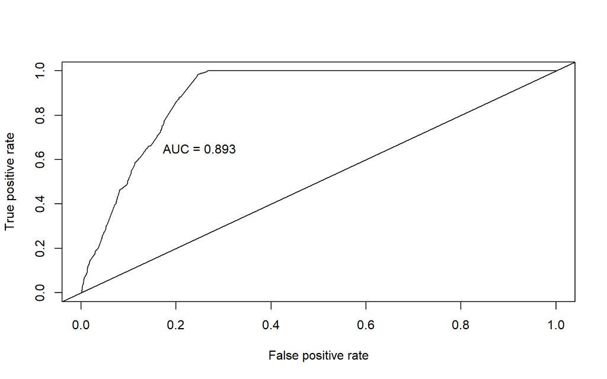

```r
log.preds <- logit.lasso %>% predict(data.test, type = "response")
log.perf <- prediction(log.preds, data.test$is_violent_recid)
roc.perf <- performance(log.perf, measure = "tpr", x.measure = "fpr")
auc.train <- performance(log.perf, measure = "auc")
auc.train <- auc.train@y.values

plot(roc.perf)
abline(a=0, b= 1)
text(x = .25, y = .65 ,paste("AUC = ", round(auc.train[[1]],3), sep = ""))
```

> The ROC curve also shows that this is a well performing model for predicting is_violent_recid.

#### Findings & Bias Analysis

```r
#Violent Recid

data.test$predictions <- log.lasso.pred
data.test$predictions[data.test$predictions == "No Recid"] <- 0
data.test$predictions[data.test$predictions == "Yes Recid"] <- 1
data.test$predictions <- as.numeric(data.test$predictions)

#Race
race.r <- ggplot(data.test, aes(x = race, fill = as.factor(predictions))) + geom_bar(position = 'dodge') +
  scale_fill_discrete(name = "Recidivated", labels = c("No", "Yes")) +
  xlab('Race') +
  ylab('Number of People in Bin')

summary(aov(predictions ~ race, data.test))
```

```
##               Df Sum Sq Mean Sq F value  Pr(>F)
## race           5  0.083 0.01653   4.804 0.00022 ***
## Residuals   4901 16.858 0.00344
## ---
## Signif. codes:  0 '***' 0.001 '**' 0.01 '*' 0.05 '.' 0.1 ' ' 1
```

```r
kable(data.test %>%
  group_by(race) %>%
  summarize_at(c("predictions"), mean), digits = 2)
```

| race | predictions |
| --- | --- |
| Caucasian | 0.00 |
| African-American | 0.01 |
| Asian | 0.00 |
| Hispanic | 0.00 |
| Native American | 0.07 |
| Other | 0.00 |

```r
#Age
age.r <- ggplot(data.test, aes(x = age, fill = as.factor(predictions))) + geom_histogram(position = "fill") +
  scale_fill_discrete(name = "Recidivated", labels = c("No", "Yes")) +
  xlab('Age') +
  ylab('Number of People in Bin')

#Sex
sex.r <- ggplot(data.test, aes(x = sex, fill = as.factor(predictions))) + geom_bar(position = 'dodge') +
  scale_fill_discrete(name = "Recidivated", labels = c("No", "Yes")) +
  xlab('Sex') +
  ylab('Number of People in Bin')

t.test(predictions ~ sex, data.test)
```

```
##
##  Welch Two Sample t-test
##
## data:  predictions by sex
## t = 1.1175, df = 2196.9, p-value = 0.2639
## alternative hypothesis: true difference in means is not equal to 0
## 95 percent confidence interval:
##  -0.001437316  0.005245429
## sample estimates:
##   mean in group Male mean in group Female
##          0.003861004          0.001956947
```

```r
kable(data.test %>%
  group_by(sex) %>%
  summarize_at(c("predictions"), mean), digits = 2)
```

| sex | predictions |
| --- | --- |
| Male | 0 |
| Female | 0 |

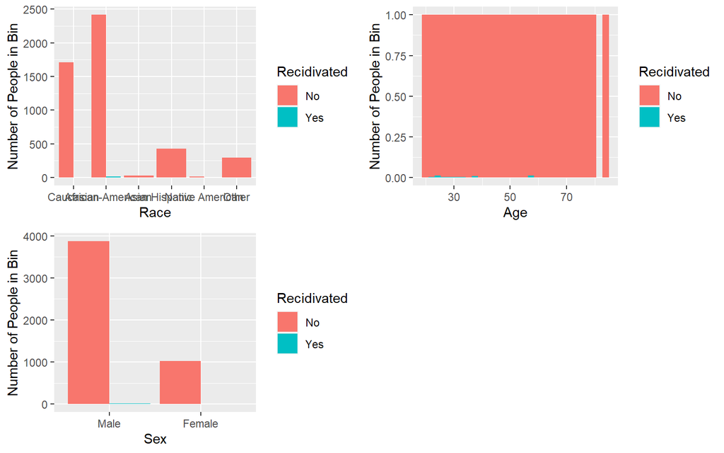

```r
grid.arrange(race.r, age.r, sex.r, ncol = 2)
```

For this variable, I fit 4 models – Logistic Lasso, regular logistic with lasso-selected predictors, regular logistic with boruta-selected predictors, and a full model. A full model was included because both lasso and boruta feature selections resulted in a fair number of predictors being removed, so a full model is included for completeness.

**Was the Model Biased?**

### Model Summary

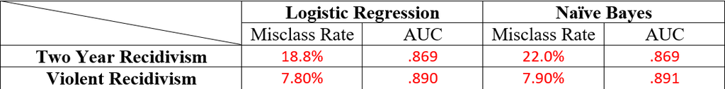

> I find that Logistic Regression produced the best misclassification rates compared to Naive Bayes in both Two Year and Violent recidivism. They both had very similar AUC values, so I picked the model with the lowest misclassification rates. Logistic Regression with Lasso-Selected Coefficients classified recidivism rates really well.

Back to top

## KAY – Linear and Quadratic Discriminant Analysis

To be coherent with the team, I used the dataset that only keeps the necessary variables. I adjusted my data frame by changing the “race” variable to a vector and then re-ordering it by having “Caucasian” listed as the first one, so it could be seen as a baseline. The reason for it is that after I first ran the LDA and QDA model, “African American” was used as the baseline. It was not ideal for the interpretation, especially when one of our goals is to examine whether the system is racist. I also removed the “c_charge_degree” because it gave an error of having constant values when running the LDA model. Two data frames were created for is_recid and is_violent_recid respectively. For is_recid, the variable “is_violent_recid” is omitted because including it as an indicator variable may create bias, considering it could be highly correlated with the outcome variable. The reason is the same for is_violent_recid. There are 12 variables each in the data frames of “is_recid” and “is_violent_recid” for LDA and QDA models.

I also tried a method suggested by Mueller (2019), which was to perform a rank for variables in terms of importance from a glm and then fit these variables to an LDA to see if the accuracy rate improves. My pre-analysis shows that there was barely any change (a 0.001 increase). Considering my findings, I fit a full model to the discriminant analyses.

### Part One: Data exploratory

#### Read data (csv file), data processing, and important variables exploratory

```r
rm(list=ls())

# read csv file to load the data
recid <- read.csv("recid_data.csv", header = TRUE)

# Delete Irrelevant Columns
# We don't need peoples' name do predict if that person will recid
recid$name=NULL
recid$first=NULL
recid$last=NULL

# We don't need age because we have age catagory
recid$age_cat=NULL

# Remove anything related to COMPAS
recid$compas_screening_date=NULL
recid$decile_score=NULL
recid$c_days_from_compas=NULL

# Case number/Identification number is an identification of the case, so won't be needed
recid$r_case_number=NULL
recid$vr_case_number=NULL
recid$X=NULL
recid$person_id=NULL

# Date of birth not needed becasue we have age category
recid$dob=NULL

# We don't need the what date the person was arrested because getting arrested in specific date has nothing to do with if the person will be recid or not. Also, we have to count of how many times the person was arrested.
recid$c_arrest_date=NULL
recid$c_offense_date=NULL
recid$r_offense_date=NULL
recid$r_jail_in=NULL
recid$r_jail_out=NULL
recid$vr_offense_date=NULL

# vr_charge or r_charge degree is not needed becasue this is a description of violent recidivism
recid$vr_charge_degree=NULL
recid$r_charge_degree=NULL

recid$r_days_from_arrest=NULL

recid$num_r_cases=NULL

# Delete Irrelevant Rows
table(recid$c_charge_degree)
```

```
##
## (CO3)  (CT)  (F1)  (F2)  (F3)  (F5)  (F6)  (F7)  (M1)  (M2) (MO3) (NI0) (TCX)
##     1     1   152   821  5265     5     5    94  2680   734    67     6     1
##   (X)
##     1
```

```r
x1 = which(recid$c_charge_degree=="(CO3)")
recid = recid[-x1,]
x2 = which(recid$c_charge_degree=="(CT)")
recid = recid[-x2,]
x3 = which(recid$c_charge_degree=="(TCX)")
recid = recid[-x3,]
x4 = which(recid$c_charge_degree=="(X)")
recid = recid[-x4,]
x5 = which(recid$c_charge_degree=="(F5)")
recid = recid[-x5,]
x6 = which(recid$c_charge_degree=="(F6)")
recid = recid[-x6,]
x7 = which(recid$c_charge_degree=="(NI0)")
recid = recid[-x7,]
table(recid$c_charge_degree)
```

```
##
## (CO3)  (CT)  (F1)  (F2)  (F3)  (F5)  (F6)  (F7)  (M1)  (M2) (MO3) (NI0) (TCX)
##     0     0   152   821  5265     0     0    94  2680   734    67     0     0
##   (X)
##     0
```

```r
# reorder the race variables and make Caucasian the baseline
recid$race = factor(recid$race, levels = c("Caucasian","African-American","Asian","Hispanic","Native American","Other"))

rm(list=setdiff(ls(), "recid"))
```

### Part Two: Model training and validation

#### LDA model 1: “is_recid”

```r
# create a dataframe with variables except "is_violent_recid"
df1 <- subset(recid, select = c(sex, race, age, juv_fel_count, juv_misd_count, juv_other_count, priors_count, is_recid, count.prior.jail, count.prior.prison, timeinjail, timeinprison))

# split into training and validation sets
set.seed(2)
train.is_recid <- sample(1:nrow(df1), 0.8*nrow(df1))
test.is_recid <- setdiff(1:nrow(df1),train.is_recid)

#create a dataframe of test set
df.test <- df1 %>% filter(row_number() %in% test.is_recid)

# fit the lda model to the training data set
lda.fit.is_recid <- lda(is_recid~., data=df1, subset=train.is_recid)
lda.fit.is_recid
```

```
## Call:
## lda(is_recid ~ ., data = df1, subset = train.is_recid)
##
## Prior probabilities of groups:
##         0         1
## 0.6681529 0.3318471
##
## Group means:
##     sexMale raceAfrican-American   raceAsian raceHispanic raceNative American
## 0 0.7717827            0.4551001 0.005910391   0.10238322         0.003431840
## 1 0.8502879            0.6023033 0.003071017   0.06602687         0.002303263
##    raceOther      age juv_fel_count juv_misd_count juv_other_count priors_count
## 0 0.06730219 36.36244    0.03965682     0.04385129      0.06692088     2.208008
## 1 0.04491363 32.34894    0.10556622     0.14165067      0.16161228     4.781574
##   count.prior.jail count.prior.prison timeinjail timeinprison
## 0         1.345853          0.3195424   18.86196     103.9353
## 1         3.042994          0.6034549   23.02783     211.1939
##
## Coefficients of linear discriminants:
##                                LD1
## sexMale               0.2456270718
## raceAfrican-American  0.1963835441
## raceAsian            -0.1171255526
## raceHispanic         -0.0245141393
## raceNative American  -0.2678651692
## raceOther            -0.0398447124
## age                  -0.0166707913
## juv_fel_count         0.0450023744
## juv_misd_count        0.0707335112
## juv_other_count       0.0560447482
## priors_count          0.0417633413
## count.prior.jail      0.6516008721
## count.prior.prison   -0.0208121741
## timeinjail            0.0001075972
## timeinprison          0.0001033417
```

- Prior Probabilities of groups show that 66.81529% of the training data didn’t recidivate and 33.18471% recidivated.
- Group means for sexMale indicates the variable Male has a slightly greater influence on recividism (0.8502879) than on non-recividism (0.7717827).
- Group means show that Asian, Hispanic, Native American, and Other are less likely to recividate.
- However, group mean also shows African Americans are more likely to recividate (0.6023033) than non-recividism (0.4551001)
- All variables about criminial history (juv_fel_count, priors_count, count.prior.jail, etc.) indicate that defenders with criminal history are more likely to recividate.
- The coefficient of linear discriminants for African American is positive while other races are not, indicating that compared to Caucasian (baseline), being an African American are more likely to be classified as recividism.
- We may say that the system is racist against African Americans in terms of recividsm compared to other races.

#### LDA model 1 evaluation: misclassification rate and ROC curve

```r
# fit the lda model to the test dataframe
lda.pred <- predict(lda.fit.is_recid, newdata = df.test)
names(lda.pred)
```

```
## [1] "class"     "posterior" "x"
```

```r
lda.class <- lda.pred$class

# compare the prediction to the test set using a confusion matrix
test.true <- df1$is_recid[test.is_recid]
confusion_matrix.lda <- table(lda.class, test.true)
confusion_matrix.lda
```

```
##          test.true
## lda.class    0    1
##         0 1237  327
##         1   95  304
```

```r
# calcualte the misclassification rate
misclass.rate.lda <- (confusion_matrix.lda[1,2]+confusion_matrix.lda[2,1])/nrow(df.test)
misclass.rate.lda
```

```
## [1] 0.2149771
```

> The model is fitted to the test data set. Model evaluations are based on the misclassification rate and the ROC curve, more specifically, the AUC. A statistical difference test is conducted to see if the model is biased.

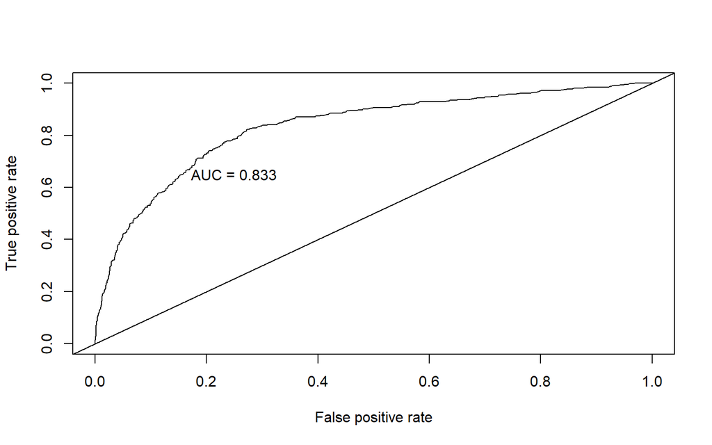

```r
# Construct a ROC curve:
# Get the posteriors as a dataframe

lda.pred.posteriors <- as.data.frame(lda.pred$posterior)

# Evaluate the model

pred <- prediction(lda.pred.posteriors[,2], df.test$is_recid)
roc.perf = performance(pred, measure = "tpr", x.measure = "fpr")
auc.train <- performance(pred, measure = "auc")
auc.train <- auc.train@y.values
# Plot
plot(roc.perf)
abline(a=0, b= 1)
text(x = .25, y = .65 ,paste("AUC = ", round(auc.train[[1]],3), sep = ""))
```

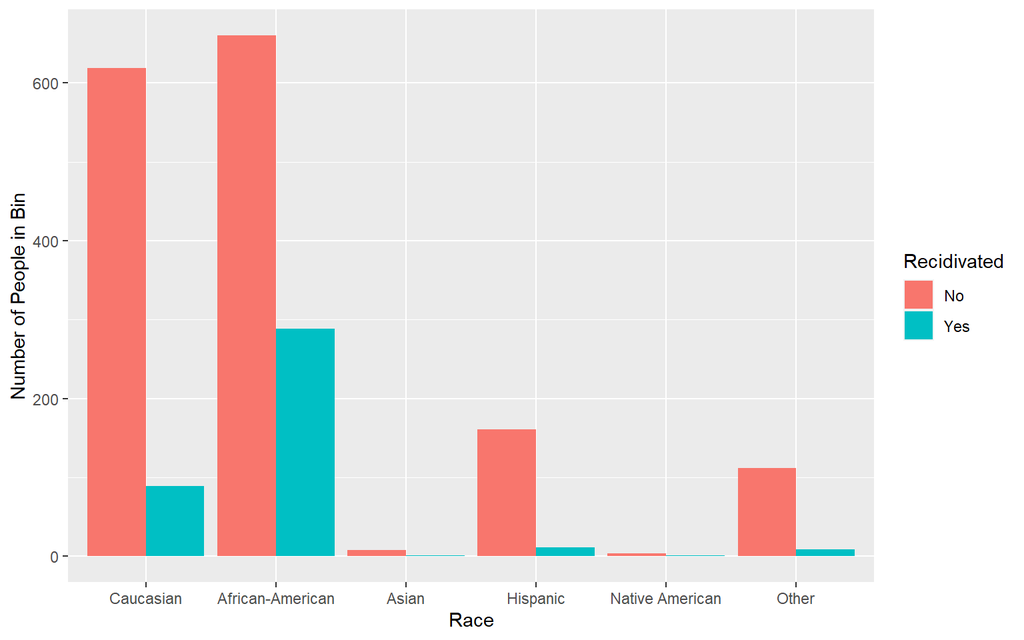

```r
#Is the model biased in terms of race?
df.test$predictions <- lda.class
df.test$predictions[df.test$predictions == "No Recid"] <- 0
df.test$predictions[df.test$predictions == "Yes Recid"] <- 1
df.test$predictions <- as.numeric(df.test$predictions)

#Race
race.r <- ggplot(df.test, aes(x = race, fill = as.factor(predictions))) + geom_bar(position = 'dodge') +
  scale_fill_discrete(name = "Recidivated", labels = c("No", "Yes")) +
  xlab('Race') +
  ylab('Number of People in Bin')

race.r
```

```r
summary(aov(predictions ~ race, df.test))
```

```
##               Df Sum Sq Mean Sq F value Pr(>F)
## race           5  19.26   3.853   25.25 <2e-16 ***
## Residuals   1957 298.63   0.153
## ---
## Signif. codes:  0 '***' 0.001 '**' 0.01 '*' 0.05 '.' 0.1 ' ' 1
```

```r
kable(df.test %>%
  group_by(race) %>%
  summarize_at(c("predictions"), mean), digits = 2)
```

| race | predictions |
| --- | --- |
| Caucasian | 1.13 |
| African-American | 1.30 |
| Asian | 1.11 |
| Hispanic | 1.06 |
| Native American | 1.20 |
| Other | 1.07 |

```r
summary(aov(predictions ~ race, df.test[df.test$race != "African-American",]))
```

```
##               Df Sum Sq Mean Sq F value Pr(>F)
## race           4   0.73 0.18324   1.886  0.111
## Residuals   1010  98.13 0.09716
```

- The misclassification rate is 21.50%.
- The ROC curve has an AUC of 0.833.
- The model is biased. African Americans were predicted to recidivate more often than other races (=1.30) and it is significant at the 0.05 level with p-value < 2e-16.
- When African Americans are removed from the data set, the difference is not significant anymore with p-value = 0.111
- Conclusion 1: LDA model for is_recid gives a misclassfication rate = 21.50%.
- LDA model for is_recid gives a ROC curve with AUC = 0.833.

#### LDA model 2: “is_violent_recid”

```r
# create a dataframe with variables except "is_recid"
df1.violent <- subset(recid, select = c(sex, race, age, juv_fel_count, juv_misd_count, juv_other_count, priors_count, is_violent_recid, count.prior.jail, count.prior.prison, timeinjail,timeinprison))

# split into training and validation sets
set.seed(2)
train.is_violent_recid <- sample(1:nrow(df1.violent), 0.8 * nrow(df1.violent))
test.is_violent_recid <- setdiff(1:nrow(df1.violent),train.is_violent_recid)

#create a dataframe of test set
df.test2 <- df1.violent %>% filter(row_number() %in% test.is_violent_recid)

# fit the lda model to the training data set
lda.fit.is_violent_recid <- lda(is_violent_recid~., data=df1.violent, subset=train.is_violent_recid)
lda.fit.is_violent_recid
```

```
## Call:
## lda(is_violent_recid ~ ., data = df1.violent, subset = train.is_violent_recid)
##
## Prior probabilities of groups:
##          0          1
## 0.92343949 0.07656051
##
## Group means:
##     sexMale raceAfrican-American   raceAsian raceHispanic raceNative American
## 0 0.7911436            0.4944130 0.004966202   0.09325424         0.002896951
## 1 0.8785358            0.6189684 0.004991681   0.05490849         0.004991681
##    raceOther      age juv_fel_count juv_misd_count juv_other_count priors_count
## 0 0.06028418 35.32570    0.05393847     0.06552628      0.08925369     2.926197
## 1 0.05490849 31.47088    0.15307820     0.20632280      0.20798669     4.700499
##   count.prior.jail count.prior.prison timeinjail timeinprison
## 0         1.790592          0.3935715   19.51159     130.4572
## 1         3.337770          0.6572379   29.08319     248.9459
##
## Coefficients of linear discriminants:
##                                LD1
## sexMale               0.2958845875
## raceAfrican-American  0.1979970319
## raceAsian             0.4095361664
## raceHispanic         -0.0688810913
## raceNative American   0.7996058128
## raceOther             0.2187912558
## age                  -0.0105429079
## juv_fel_count         0.2337230598
## juv_misd_count        0.3598387673
## juv_other_count       0.1308619812
## priors_count         -0.0213290796
## count.prior.jail      0.5999233178
## count.prior.prison    0.0293765792
## timeinjail            0.0016781294
## timeinprison          0.0001422081
```

- Prior Probabilities of groups show that 92.34% of the observarions in training dataset didn’t have a violent recidivism, and 7.656% had violent recidivism.
- Group mean for sexMale indicates that the variable Male has a slightly greater influence on violent recividism (0.8785358) than without violent recividism (0.7911436).
- Group mean for whether Asians had violent recividism are almost equal, and the overall percentages are very small (about 0.4%).
- Group means for Caucasian, Hispanic, and Other show that these races are less likely to have violent recividism.
- Group mean for African Americans show that there are more violent recividism (0.6189684); the results are similar to is_recid.
- All variables about criminial history (juv_fel_count, priors_count, count.prior.jail, etc.) indicate that defenders with criminal history are more likely to recividate.
- The coefficients of linear discriminants for African American, Native American, other are positive, indicating that compared to Caucasian (baseline), the system is more likely to classifed these races to violent recividism. It is not necesarily racist against African Americans in terms of violent recividsm.

#### LDA model 2 evaluation: misclassification rate and ROC curve

```r
# fit the lda model to the test dataframe
lda.pred2 <- predict(lda.fit.is_violent_recid, newdata = df.test2)
names(lda.pred2)
```

```
## [1] "class"     "posterior" "x"
```

```r
lda.class2 <- lda.pred2$class

# compare the prediction to test set using confusion matrix
test.true2 <- df1.violent$is_violent_recid[test.is_violent_recid]
confusion_matrix.lda2 <- table(lda.class2, test.true2)
confusion_matrix.lda2
```

```
##           test.true2
## lda.class2    0    1
##          0 1764  141
##          1   42   16
```

```r
# calcualte the misclassification rate
misclass.rate.lda2 <- (confusion_matrix.lda2[1,2]+confusion_matrix.lda2[2,1])/nrow(df.test2)
misclass.rate.lda2
```

```
## [1] 0.09322466
```

> The LDA model is fitted to the test data set. Model evaluations are based on the misclassification rate and the ROC curve, more specifically, the AUC. A statistical difference test is conducted to see if the model is biased.

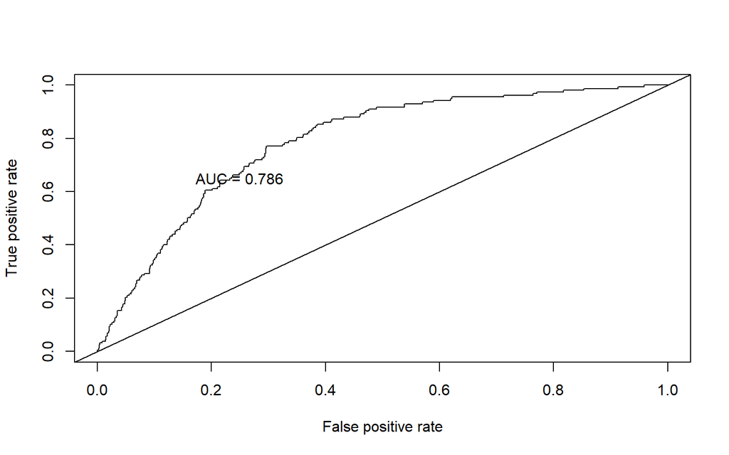

```r
# Construct a ROC curve:
# Get the posteriors as a dataframe
lda.pred.posteriors2 <- as.data.frame(lda.pred2$posterior)

# Evaluate the model
pred2 <- prediction(lda.pred.posteriors2[,2], df.test2$is_violent_recid)
roc.perf2 = performance(pred2, measure = "tpr", x.measure = "fpr")
auc.train2 <- performance(pred2, measure = "auc")
auc.train2 <- auc.train2@y.values
# Plot
plot(roc.perf2)
abline(a=0, b= 1)
text(x = .25, y = .65 ,paste("AUC = ", round(auc.train2[[1]],3), sep = ""))
```

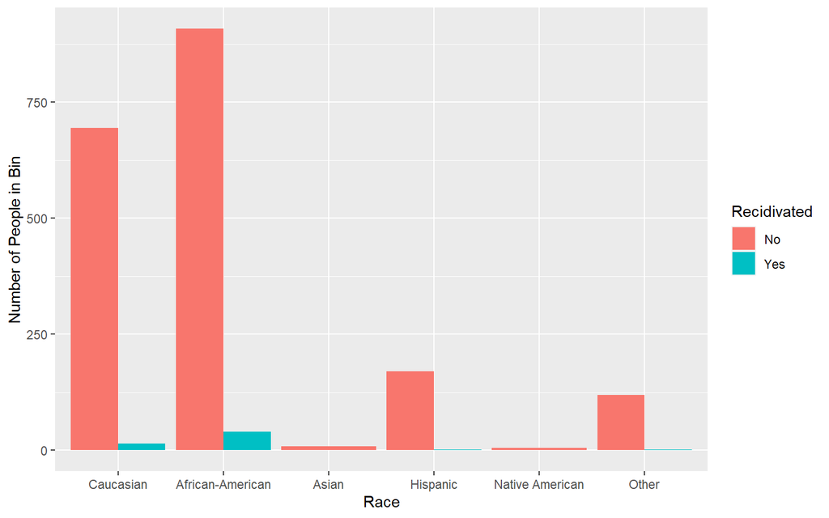

```r
#Is the model biased in terms of race?
df.test2$predictions <- lda.class2
df.test2$predictions[df.test2$predictions == "No Recid"] <- 0
df.test2$predictions[df.test2$predictions == "Yes Recid"] <- 1
df.test2$predictions <- as.numeric(df.test2$predictions)

#Race
race.r <- ggplot(df.test2, aes(x = race, fill = as.factor(predictions))) + geom_bar(position = 'dodge') +
  scale_fill_discrete(name = "Recidivated", labels = c("No", "Yes")) +
  xlab('Race') +
  ylab('Number of People in Bin')

race.r
```

```r
summary(aov(predictions ~ race, df.test2))
```

```
##               Df Sum Sq Mean Sq F value Pr(>F)
## race           5   0.31 0.06144   2.148 0.0573 .
## Residuals   1957  55.98 0.02860
## ---
## Signif. codes:  0 '***' 0.001 '**' 0.01 '*' 0.05 '.' 0.1 ' ' 1
```

```r
kable(df.test2 %>%
  group_by(race) %>%
  summarize_at(c("predictions"), mean), digits = 2)
```

| race | predictions |
| --- | --- |
| Caucasian | 1.02 |
| African-American | 1.04 |
| Asian | 1.00 |
| Hispanic | 1.01 |
| Native American | 1.00 |
| Other | 1.02 |

```r
summary(aov(predictions ~ race, df.test2[df.test2$race != "African-American",]))
```

```
##               Df Sum Sq  Mean Sq F value Pr(>F)
## race           4  0.014 0.003485   0.199  0.939
## Residuals   1010 17.667 0.017492
```

- Conclusion 2: LDA model for is_violent_recid gives a misclassfication rate = 9.322%.
- LDA model for is_violent_recid gives a ROC curve with AUC = 0.786.
- The misclassification rate is 9.322%.
- The ROC curve has an AUC of 0.786.
- The coefficients of linear discriminants for African American, Native American, and Other are positive, indicating that compared to Caucasian (baseline), the system is more likely to classify these races to violent recidivism. It is not necessarily biased against African Americans in terms of violent recidivism.
- A significance analysis also shows that the model is not biased. Although African Americans are predicted to have recidivism slightly higher than other races, the difference is not significant at a 0.05 level. After removing African Americans, we no longer have statistical significance.

#### QDA model 1: “is_recid”

```r
# create a dataframe without is_violent_recid to avoid colinearity
df2 <- recid[,c("is_recid", "sex", "race", "age", "juv_fel_count", "juv_misd_count", "juv_other_count", "priors_count", "count.prior.jail", "count.prior.prison", "timeinjail","timeinprison")]

set.seed(2)
ind = sample(2,nrow(df2),replace=TRUE,prob=c(0.7,0.3))
train.is_recid.qda = df2[ind==1,]
test.is_recid.qda = df2[ind==2,]

# fit the lda model to the training data set
qda.fit.is_recid <- qda(is_recid~., data=train.is_recid.qda)
qda.fit.is_recid
```

```
## Call:
## qda(is_recid ~ ., data = train.is_recid.qda)
##
## Prior probabilities of groups:
##        0        1
## 0.668913 0.331087
##
## Group means:
##     sexMale raceAfrican-American   raceAsian raceHispanic raceNative American
## 0 0.7645642            0.4500657 0.006351292   0.10183968         0.002628121
## 1 0.8530973            0.5933628 0.003539823   0.06327434         0.002654867
##    raceOther      age juv_fel_count juv_misd_count juv_other_count priors_count
## 0 0.06811213 36.31559    0.03613666     0.04402102      0.06373193     2.168857
## 1 0.04557522 32.07257    0.10707965     0.14955752      0.16504425     4.711947
##   count.prior.jail count.prior.prison timeinjail timeinprison
## 0         1.339028          0.2989488   18.73007     99.41272
## 1         3.049558          0.5597345   23.65398    199.60752
```

#### QDA model 1 evaluation: misclassification rate and ROC curve

```r
# fit the lda model to the test dataframe
qda.pred1 <- predict(qda.fit.is_recid, test.is_recid.qda)
names(qda.pred1)
```

```
## [1] "class"     "posterior"
```

```r
qda.class1 <- qda.pred1$class
confusion_matrix.qda1 <- table(qda.class1,test.is_recid.qda$is_recid)
confusion_matrix.qda1
```

```
##
## qda.class1    0    1
##          0 1752  523
##          1  259  453
```

```r
misclassification.rate.qda1 <- (confusion_matrix.qda1[1,2]+confusion_matrix.qda1[2,1])/nrow(df2)
misclassification.rate.qda1
```

```
## [1] 0.07969021
```

> The QDA model is fitted to the test data set. Model evaluations are based on the misclassification rate and the ROC curve, more specifically, the AUC. A statistical difference test is conducted to see if the model is biased.

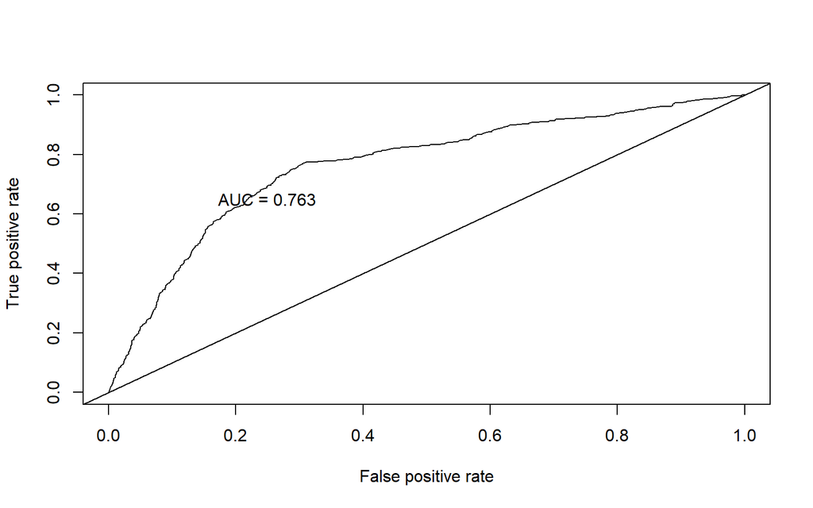

```r
# Construct a ROC curve:
# Get the posteriors as a dataframe
qda.pred.posteriors1 <- as.data.frame(qda.pred1$posterior)

# Evaluate the model
pred3 <- prediction(qda.pred.posteriors1[,2], test.is_recid.qda$is_recid)
roc.perf3 = performance(pred3, measure = "tpr", x.measure = "fpr")
auc.train3 <- performance(pred3, measure = "auc")
auc.train3 <- auc.train3@y.values
# Plot
plot(roc.perf3)
abline(a=0, b= 1)
text(x = .25, y = .65 ,paste("AUC = ", round(auc.train3[[1]],3), sep = ""))
```

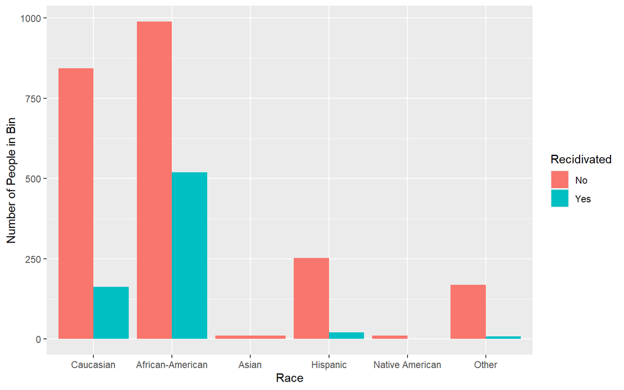

```r
#Is the model biased in terms of race?
test.is_recid.qda$predictions <- qda.class1
test.is_recid.qda$predictions[test.is_recid.qda$predictions == "No Recid"] <- 0
test.is_recid.qda$predictions[test.is_recid.qda$predictions == "Yes Recid"] <- 1
test.is_recid.qda$predictions <- as.numeric(test.is_recid.qda$predictions)

#Race
race.r <- ggplot(test.is_recid.qda, aes(x = race, fill = as.factor(predictions))) + geom_bar(position = 'dodge') +
  scale_fill_discrete(name = "Recidivated", labels = c("No", "Yes")) +
  xlab('Race') +
  ylab('Number of People in Bin')

race.r
```

```r
summary(aov(predictions ~ race, test.is_recid.qda))
```

```
##               Df Sum Sq Mean Sq F value Pr(>F)
## race           5   37.4   7.471   44.11 <2e-16 ***
## Residuals   2981  504.9   0.169
## ---
## Signif. codes:  0 '***' 0.001 '**' 0.01 '*' 0.05 '.' 0.1 ' ' 1
```

```r
kable(test.is_recid.qda %>%
  group_by(race) %>%
  summarize_at(c("predictions"), mean), digits = 2)
```

| race | predictions |
| --- | --- |
| Caucasian | 1.16 |
| African-American | 1.34 |
| Asian | 1.00 |
| Hispanic | 1.08 |
| Native American | 1.09 |
| Other | 1.05 |

```r
summary(aov(predictions ~ race, test.is_recid.qda[test.is_recid.qda$race != "African-American",]))
```

```
##               Df Sum Sq Mean Sq F value     Pr(>F)
## race           4   3.27  0.8167   7.316 0.00000783 ***
## Residuals   1474 164.55  0.1116
## ---
## Signif. codes:  0 '***' 0.001 '**' 0.01 '*' 0.05 '.' 0.1 ' ' 1
```

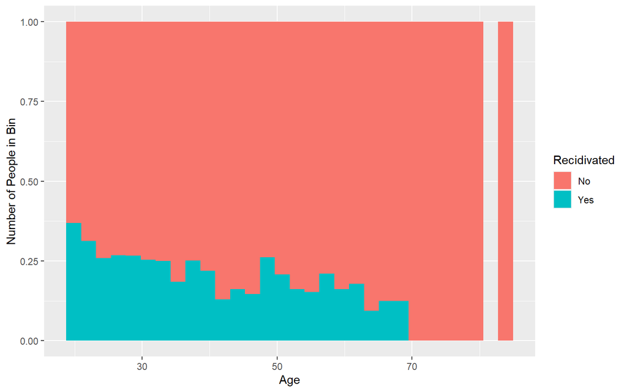

```r
#Age
ggplot(test.is_recid.qda, aes(x = age, fill = as.factor(predictions))) +
  geom_histogram(position = 'fill') +
  scale_fill_discrete(name = "Recidivated", labels = c("No", "Yes")) +
  xlab('Age') +
  ylab('Number of People in Bin')
```

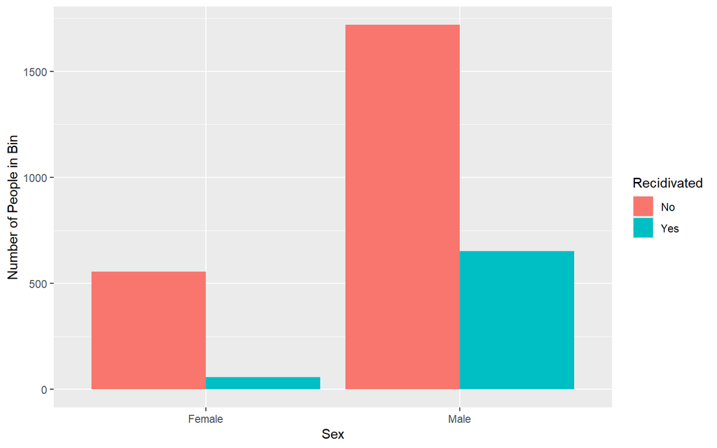

```r
#Sex
ggplot(test.is_recid.qda, aes(x = sex, fill = as.factor(predictions))) +
  geom_bar(position = 'dodge') +
  scale_fill_discrete(name = "Recidivated", labels = c("No", "Yes")) +
  xlab('Sex') +
  ylab('Number of People in Bin')
```

```r
t.test(predictions ~ sex, data = test.is_recid.qda)
```

```
##
##  Welch Two Sample t-test
##
## data:  predictions by sex
## t = -11.947, df = 1431.8, p-value < 2.2e-16
## alternative hypothesis: true difference in means is not equal to 0
## 95 percent confidence interval:
##  -0.2088107 -0.1499096
## sample estimates:
## mean in group Female   mean in group Male
##             1.095935             1.275295
```

#### QDA model 2: “is_violent_recid”

```r
# create a dataframe without is_recid to avoid colinearity
df3 <- recid[,c("is_violent_recid", "sex", "race", "age", "juv_fel_count", "juv_misd_count", "juv_other_count", "priors_count", "count.prior.jail", "count.prior.prison", "timeinjail","timeinprison")]

set.seed(2)
ind = sample(2,nrow(df3),replace=TRUE,prob=c(0.7,0.3))
train.is_violent_recid.qda = df3[ind==1,]
test.is_violent_recid.qda = df3[ind==2,]

# fit the lda model to the training data set
qda.fit.is_violent_recid <- qda(is_violent_recid~., data=train.is_violent_recid.qda)
qda.fit.is_violent_recid
```

```
## Call:
## qda(is_violent_recid ~ ., data = train.is_violent_recid.qda)
##
## Prior probabilities of groups:
##          0          1
## 0.92396718 0.07603282
##
## Group means:
##     sexMale raceAfrican-American   raceAsian raceHispanic raceNative American
## 0 0.7864278            0.4864436 0.005549390   0.09227842         0.002378310
## 1 0.8843931            0.6319846 0.003853565   0.05009634         0.005780347
##    raceOther      age juv_fel_count juv_misd_count juv_other_count priors_count
## 0 0.06151895 35.18392    0.05216426     0.06849532      0.08974156     2.867449
## 1 0.05009634 31.59152    0.15028902     0.20616570      0.18882466     4.753372
##   count.prior.jail count.prior.prison timeinjail timeinprison
## 0         1.784208          0.3689551   19.58380     125.4194
## 1         3.377649          0.5838150   29.79672     219.6753
```

#### QDA model 2: validation and misclassification rate

```r
# fit the lda model to the test dataframe
qda.pred2 <- predict(qda.fit.is_violent_recid, test.is_violent_recid.qda)
names(qda.pred2)
```

```
## [1] "class"     "posterior"
```

```r
qda.class2 <- qda.pred2$class
confusion_matrix.qda2 <- table(qda.class2,test.is_violent_recid.qda$is_violent_recid)
confusion_matrix.qda2
```

```
##
## qda.class2    0    1
##          0 2551  190
##          1  197   49
```

```r
misclassification.rate.qda2 <- (confusion_matrix.qda2[1,2]+confusion_matrix.qda2[2,1])/nrow(df3)
misclassification.rate.qda2
```

```
## [1] 0.03943748
```

> The QDA model is fitted to the test data set. Model evaluations are based on the misclassification rate and the ROC curve, more specifically, the AUC. A statistical difference test is conducted to see if the model is biased.

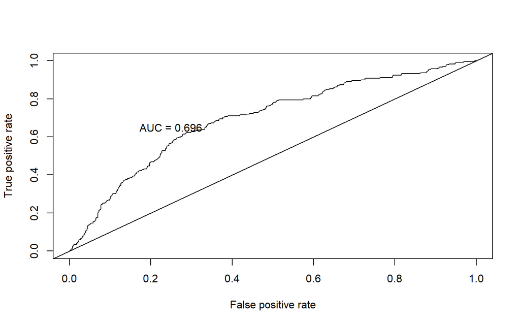

```r
# Construct a ROC curve:
# Get the posteriors as a dataframe
qda.pred.posteriors2 <- as.data.frame(qda.pred2$posterior)

# Evaluate the model
pred4 <- prediction(qda.pred.posteriors2[,2], test.is_violent_recid.qda$is_violent_recid)
roc.perf4 = performance(pred4, measure = "tpr", x.measure = "fpr")
auc.train4 <- performance(pred4, measure = "auc")
auc.train4 <- auc.train4@y.values
# Plot
plot(roc.perf4)
abline(a=0, b= 1)
text(x = .25, y = .65 ,paste("AUC = ", round(auc.train4[[1]],3), sep = ""))
```

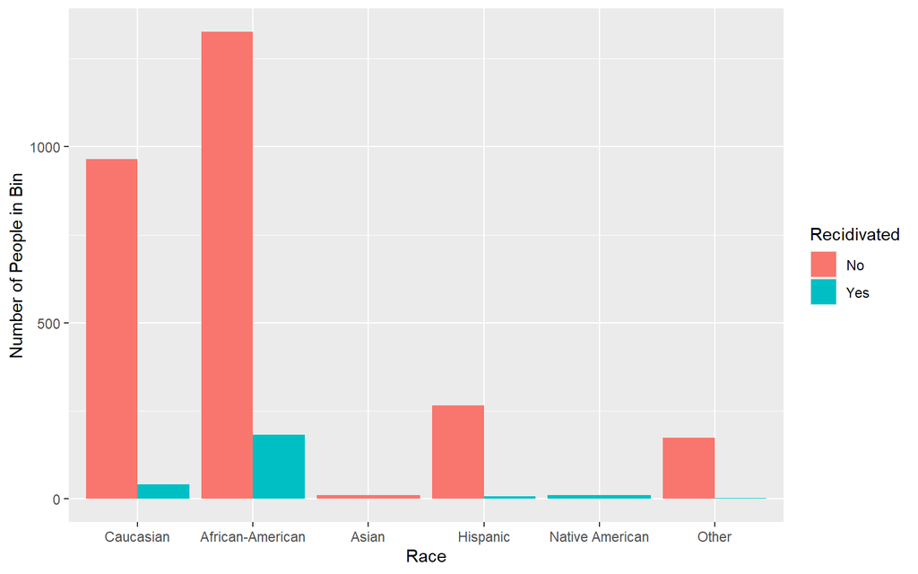

```r
qda.pred.is_recid <- qda.class1
qda.pred.vis_recid <- qda.class2
qda.test.data.r <- test.is_recid.qda$is_recid
qda.test.data.v <- test.is_violent_recid.qda$is_violent_recid

#Is the model biased in terms of race?
test.is_violent_recid.qda$predictions <- qda.class2
test.is_violent_recid.qda$predictions[test.is_violent_recid.qda$predictions == "No Recid"] <- 0
test.is_violent_recid.qda$predictions[test.is_violent_recid.qda$predictions == "Yes Recid"] <- 1
test.is_violent_recid.qda$predictions <- as.numeric(test.is_violent_recid.qda$predictions)

#Race
race.r <- ggplot(test.is_violent_recid.qda, aes(x = race, fill = as.factor(predictions))) + geom_bar(position = 'dodge') +
  scale_fill_discrete(name = "Recidivated", labels = c("No", "Yes")) +
  xlab('Race') +
  ylab('Number of People in Bin')

race.r
```